# TeilB

### Kalibrierung

```python
predictions_test_dict = {}
predictions_freq_dict = {}

# =========================
# 1. Intercept-Only
# =========================
model_name = "Intercept-Only"

pred_test_int = exposure_test * baseline_frequency
freq_test_int = np.full_like(exposure_test, baseline_frequency)

predictions_test_dict[model_name] = pred_test_int
predictions_freq_dict[model_name] = freq_test_int


# =========================
# 2. GLM
# =========================
model_name = "GLM"

pred_test_glm = glm_full.predict(X_test, offset=np.log(X_test["Exposure"]))
freq_test_glm = pred_test_glm / exposure_test

predictions_test_dict[model_name] = pred_test_glm
predictions_freq_dict[model_name] = np.clip(freq_test_glm, 1e-12, None)


# =========================
# 3. LASSO
# =========================
model_name = "LASSO"

pred_test_lasso = lasso_final_result.predict(X_test_lasso_scaled_const, offset=offset_test)
freq_test_lasso = pred_test_lasso / exposure_test

predictions_test_dict[model_name] = pred_test_lasso
predictions_freq_dict[model_name] = np.clip(freq_test_lasso, 1e-12, None)


# =========================
# 4. CANN
# =========================
model_name = "CANN"

pred_test_lasso_tmp = np.asarray(
    lasso_final_result.predict(X_test_lasso_scaled_const, offset=offset_test)
).astype("float32")

pred_test_lasso_tmp = np.clip(pred_test_lasso_tmp, 1e-12, None)
log_pred_test_lasso = np.log(pred_test_lasso_tmp).reshape(-1, 1).astype("float32")

pred_test_cann = model_cann.predict(
    [X_test_cann_mat, log_pred_test_lasso]
).reshape(-1)

pred_test_cann = np.clip(pred_test_cann, 1e-12, None)
freq_test_cann = pred_test_cann / exposure_test

predictions_test_dict[model_name] = pred_test_cann
predictions_freq_dict[model_name] = freq_test_cann


# =========================
# 5. Bagging
# =========================
model_name = "Bagging"

freq_pred_test_bagging = np.clip(bagging_model.predict(X_test_tree), 1e-12, None)
pred_test_bagging = freq_pred_test_bagging * exposure_test

predictions_test_dict[model_name] = pred_test_bagging
predictions_freq_dict[model_name] = freq_pred_test_bagging


# =========================
# 6. Random Forest
# =========================
model_name = "RF"

freq_pred_test_rf = np.clip(rf_model.predict(X_test_tree), 1e-12, None)
pred_test_rf = freq_pred_test_rf * exposure_test

predictions_test_dict[model_name] = pred_test_rf
predictions_freq_dict[model_name] = freq_pred_test_rf


# =========================
# 7. LightGBM
# =========================
model_name = "LightGBM"

freq_pred_test_lgb = np.clip(final_lgb.predict(X_test_tree), 1e-12, None)
pred_test_lgb = freq_pred_test_lgb * exposure_test

predictions_test_dict[model_name] = pred_test_lgb
predictions_freq_dict[model_name] = freq_pred_test_lgb


# =========================
# 8. XGBoost
# =========================
model_name = "XGBoost"

freq_pred_test_xgb = np.clip(final_xgb.predict(X_test_tree), 1e-12, None)
pred_test_xgb = freq_pred_test_xgb * exposure_test

predictions_test_dict[model_name] = pred_test_xgb
predictions_freq_dict[model_name] = freq_pred_test_xgb


# =========================
# 9. LightGBM Monotonie
# =========================
model_name = "LightGBM mit Monotonie"

freq_pred_test_m_lgb = np.clip(lgb_mono.predict(X_test_tree), 1e-12, None)
pred_test_m_lgb = freq_pred_test_m_lgb * exposure_test

predictions_test_dict[model_name] = pred_test_m_lgb
predictions_freq_dict[model_name] = freq_pred_test_m_lgb


# =========================
# 10. XGBoost Monotonie
# =========================
model_name = "XGBoost mit Monotonie"

freq_pred_test_m_xgb = np.clip(xgb_mono.predict(X_test_tree), 1e-12, None)
pred_test_m_xgb = freq_pred_test_m_xgb * exposure_test

predictions_test_dict[model_name] = pred_test_m_xgb
predictions_freq_dict[model_name] = freq_pred_test_m_xgb
```

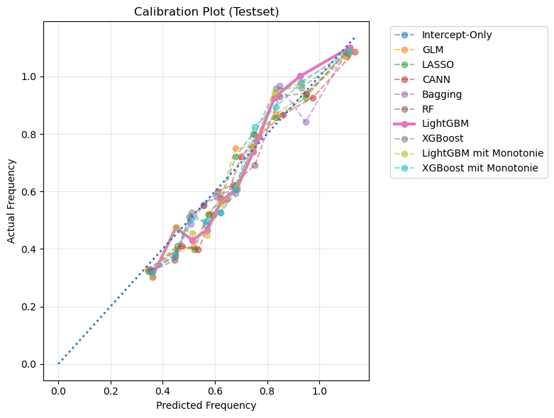

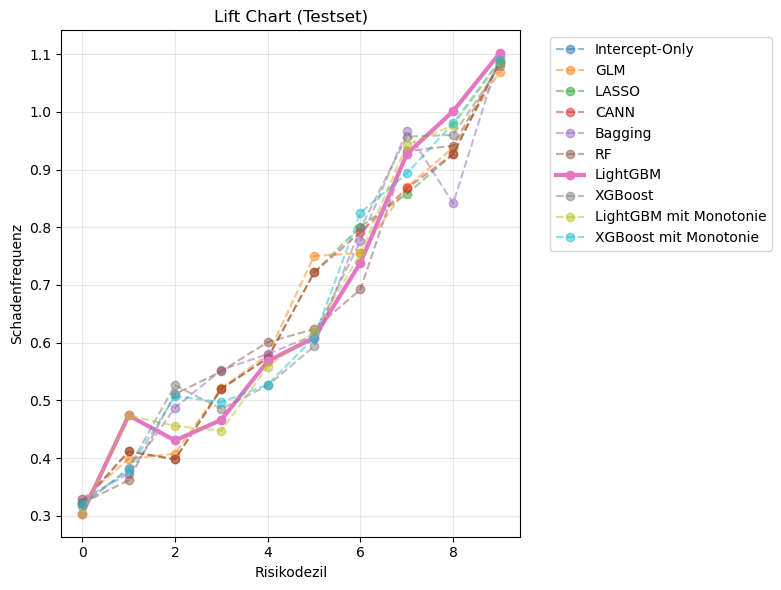

```python
def decile_analysis(pred_freq, exposure, actual):
    """
    pred_freq: vorhergesagte Frequenz (λ)
    exposure: Exposure
    actual: beobachtete Schadenanzahl
    """

    df = pd.DataFrame({
        "pred_freq": pred_freq,
        "exposure": exposure,
        "actual": actual
    })

    # Dezile basierend auf vorhergesagter Frequenz
    df["decile"] = pd.qcut(
        df["pred_freq"],
        q=10,
        labels=False,
        duplicates="drop"
    )

    # Aggregation
    grouped = df.groupby("decile").agg(
        actual_sum=("actual", "sum"),
        exposure_sum=("exposure", "sum"),
        pred_sum=("pred_freq", lambda x: np.sum(x * df.loc[x.index, "exposure"]))
    )

    # Frequenzen berechnen
    grouped["actual_freq"] = grouped["actual_sum"] / grouped["exposure_sum"]
    grouped["pred_freq"] = grouped["pred_sum"] / grouped["exposure_sum"]

    return grouped.reset_index()

#=========================
# 10. Calibration Plot
# =========================

plt.figure(figsize=(8, 6))

max_val = 0

for model_name in predictions_freq_dict:

    deciles = decile_analysis(
        predictions_freq_dict[model_name],
        exposure_test,
        obs_test
    )

    max_val = max(max_val, deciles["pred_freq"].max())

    # Highlight für CANN
    if model_name == "LightGBM":
        plt.plot(
            deciles["pred_freq"],
            deciles["actual_freq"],
            marker="o",
            linewidth=3,
            label=model_name
        )
    else:
        plt.plot(
            deciles["pred_freq"],
            deciles["actual_freq"],
            marker="o",
            alpha=0.5,
            linestyle="--",
            label=model_name
        )

# Kalibrierungsplot
plt.plot([0, max_val], [0, max_val], linestyle=":", linewidth=2)

plt.xlabel("Predicted Frequency")
plt.ylabel("Actual Frequency")
plt.title("Calibration Plot (Testset)")
plt.legend(bbox_to_anchor=(1.05, 1), loc="upper left")
plt.grid(alpha=0.3)

plt.tight_layout()
plt.show()
#=========================
# 10. Lift-Chart Plot
# =========================

plt.figure(figsize=(8, 6))

for model_name in predictions_freq_dict:

    deciles = decile_analysis(
        predictions_freq_dict[model_name],
        exposure_test,
        obs_test
    )

    if model_name == "LightGBM":
        plt.plot(
            deciles["decile"],
            deciles["actual_freq"],
            marker="o",
            linewidth=3,
            label=model_name
        )
    else:
        plt.plot(
            deciles["decile"],
            deciles["actual_freq"],
            marker="o",
            alpha=0.5,
            linestyle="--",
            label=model_name
        )

plt.xlabel("Risikodezil")
plt.ylabel("Schadenfrequenz")
plt.title("Lift Chart (Testset)")
plt.legend(bbox_to_anchor=(1.05, 1), loc="upper left")
plt.grid(alpha=0.3)

plt.tight_layout()
plt.show()
```

Der Calibration Plot zeigt, wie gut die vorhergesagte Schadenfrequenz mit der tatsächlich beobachteten Schadenfrequenz übereinstimmt. Die blaue Diagonale entspricht perfekter Kalibrierung.

Insgesamt liegen die Modellkurven relativ nah an der Diagonalen. Das bedeutet, dass die Modelle auf dem Testdatensatz insgesamt gut kalibriert sind.

##### Das beste Modell: LightGBM

B3: Modellierung des Schadendurchschnitts

*[Lernziele: 2.1, 2.2, 3.4 & 5.1 | Punkte: 18]*  
Ziel dieser Aufgabe ist die Modellierung des durchschnittlichen Schadens je Schadenereignis (*Average Claim Amount* bzw. *Severity* ). Verwenden Sie hierfür dieselben Train-/Validierungs-/Test-Splits wie in Aufgabe B2 (Frequency-Modell).

a) Datenvorbereitung und Verteilungsannahme

Filtern Sie den Datensatz auf Beobachtungen mit N_claims_year > 0 und erstellen Sie die Zielvariable AvgClaimAmount. Warum ist es sinnvoll, nur Policen mit Schäden N_claims_year > 0 für die Severity-Modellierung zu verwenden? Welche Verteilungsannahme ist für Schadenhöhen typischerweise geeignet? Führen Sie alle Schritte durch, die als Vorbereitung für die nachfolgenden Modelle notwendig sind.

## **Lösung:**

Für die Modellierung des Schadendurchschnitts werden nur Beobachtungen mit mindestens einem Schaden berücksichtigt. Der Schadendurchschnitt ist nur dann sinnvoll definiert, wenn tatsächlich ein Schadenereignis vorliegt.

Die Zielvariable wird definiert als:

$ Severity_i = \frac{Cost\_claims\_year_i}{N\_claims\_year_i} $

Policen ohne Schaden besitzen keine beobachtete Schadenhöhe. Sie enthalten Informationen zur Schadenfrequenz, aber nicht zur Severity. Daher werden sie für die Severity-Modellierung ausgeschlossen.

Zur Erstellung der Severity-Datensätze wurden die Indizes der Trainings-, Validierungs- und Testdaten verwendet, um auf den ursprünglichen Datensatz zuzugreifen.

```python
# Originaldaten anhand der bereits in Teil B1 b) erzeugten Train-/Valid-/Test-Indizes aufteilen.
# Wichtig: Es werden die ursprünglichen Daten verwendet, also vor dem Entfernen von
# `Premium` und `N_claims_year`, da `N_claims_year` zur Berechnung der Severity benötigt wird.
train_original = Input_data.loc[X_train.index].copy()
valid_original = Input_data.loc[X_valid.index].copy()
test_original  = Input_data.loc[X_test.index].copy()

# Für die Modellierung der Schadenhöhe (Severity) werden nur Verträge mit mindestens
# einem Schaden betrachtet. Bei Verträgen ohne Schaden ist keine durchschnittliche
# Schadenhöhe pro Schadenfall definiert.
train_sev = train_original[train_original["N_claims_year"] > 0].copy()
valid_sev = valid_original[valid_original["N_claims_year"] > 0].copy()
test_sev  =test_original[test_original["N_claims_year"] > 0].copy()

train_sev["Severity"] = (
    train_sev["Cost_claims_year"] / train_sev["N_claims_year"]
)

valid_sev["Severity"] = (
    valid_sev["Cost_claims_year"] / valid_sev["N_claims_year"]
)

test_sev["Severity"] = (
    test_sev["Cost_claims_year"] / test_sev["N_claims_year"]
)

# Zielvariable
target ="Severity"
y_train_sev = train_sev[target]
y_valid_sev = valid_sev[target]
y_test_sev  = test_sev[target]
```

```python
print("Train Severity:", train_sev.shape)
print("Valid Severity:", valid_sev.shape)
print("Test Severity:", test_sev.shape)

display(train_sev[["Cost_claims_year", "N_claims_year", "Severity"]].head())
```

```
Train Severity: (3131, 20)
Valid Severity: (944, 20)
Test Severity: (1044, 20)
```

|  | Cost_claims_year | N_claims_year | Severity |
| --- | --- | --- | --- |
| 15072 | 882.000000 | 1 | 882.000000 |
| 3303 | 54.020000 | 1 | 54.020000 |
| 9672 | 58.940000 | 3 | 19.646667 |
| 1048 | 882.000000 | 1 | 882.000000 |
| 8468 | 1764.000000 | 2 | 882.000000 |

### Vorbereitung für Severity-Modellierung

#### Umgang mit potenziellem Data Leakage

Im Rahmen der Severity-Modellierung wird geprüft, ob einzelne Variablen Informationen enthalten, die zu Data Leakage führen könnten.

Variablen wie `Cost_claims_year`,`N_claims_year` und die daraus abgeleitete Zielvariable `Severity` werden konsequent ausgeschlossen, da sie direkt oder indirekt Informationen über die Zielgröße enthalten.

In der Praxis wird die Prämie typischerweise auf Basis von Risikomodellen kalkuliert und enthält somit bereits verdichtete Informationen über das Risiko des Versicherungsnehmers. Die Verwendung von `Premium` als Prädiktor würde daher zu indirektem Data Leakage führen, da das Modell bereits vorhandene Tarifierungslogik reproduzieren könnte.

Aus diesem Grund wird `Premium` im Severity-Modell nicht verwendet, um eine unverzerrte Bewertung der Modellgüte zu gewährleisten.

#### Umgang mit Exposure in der Severity-Modellierung

Die Variable `Exposure` wird im Severity-Modell nicht verwendet. Während `Exposure` in der Frequency-Modellierung eine zentrale Rolle spielt, da sie die Risikodauer widerspiegelt, ist sie für die Modellierung der durchschnittlichen Schadenhöhe nicht relevant.

Die Zielvariable der Severity-Modellierung ist der durchschnittliche Schaden pro Schadenereignis. Dieser hängt primär von der Höhe einzelner Schäden ab und nicht von der Dauer der Versicherungsperiode.

Die Aufnahme von Exposure als Prädiktor könnte zu einem verzerrten Modell führen, da ein kausaler Zusammenhang zwischen Vertragsdauer und Schadenhöhe nicht gegeben ist.Z.B. ein Modell könnte falschen Zusammenhang lernen: je länger Vertragsdauer ist, desto höherer Schadenbetrag ist es. Daher wurde bewusst auf die Verwendung von Exposure verzichtet.

Stattdessen wird die Variable `N_claims_year` as Gewichtung genommen -sehen Sie dafür Teilaufgabe b)

```python
exclude_cols = ["Cost_claims_year", "Severity","Premium", "Exposure"]
X_train_sev = train_sev.drop(columns=exclude_cols)
X_valid_sev = valid_sev.drop(columns=exclude_cols)
X_test_sev =test_sev.drop(columns=exclude_cols)
print("Train:", X_train_sev.shape)
print("Valid:", X_valid_sev.shape)
print("Test:", X_test_sev.shape)
```

```
Train: (3131, 16)
Valid: (944, 16)
Test: (1044, 16)
```

Alle vorhandenen Merkmale in Feature-Set sind :

```python
X_train_sev.columns
```

```
Index(['Distribution_channel', 'Seniority', 'Lapse', 'Payment',
       'N_claims_year', 'Area', 'Second_driver', 'Power', 'Cylinder_capacity',
       'Value_vehicle', 'N_doors', 'Type_fuel', 'Weight', 'DrivAge',
       'DrivLicenceAge', 'VehAge'],
      dtype='object')
```

Davon sind folgende Merkmale kategorisch:

```python
var_cat_sev=var_cat
var_cat_sev
```

```
['Distribution_channel',
 'Payment',
 'Area',
 'Second_driver',
 'N_doors',
 'Type_fuel']
```

Davon sind die folgenden Merkmale numerisch:

```python
var_num_sev=[col for col in X_train_sev.columns if col not in var_cat_sev]
var_num_sev
```

```
['Seniority',
 'Lapse',
 'N_claims_year',
 'Power',
 'Cylinder_capacity',
 'Value_vehicle',
 'Weight',
 'DrivAge',
 'DrivLicenceAge',
 'VehAge']
```

b) Wahl und Implementierung der Evaluierungsfunktion

Bevor Sie mit der Modellierung beginnen, ist die Wahl einer geeigneten Evaluierungsmetrik entscheidend für den Vergleich der Modelle. Wählen Sie eine geeignete Evaluierungsfunktion für die Bewertung von GLM- und GAM-Modellen im Kontext der Severity- Modellierung aus und implementieren Sie die gewählte Metrik in einer Funktion. Falls Sie mehrere Metriken verwenden möchten, implementieren Sie alle relevanten Funktionen. Begründen Sie Ihre Wahl ausführlich. Sollte die Evaluierungsmetrik gewichtet werden? Wenn ja, durch welche Variable und warum?

## **Lösung:**

Da Schadenhöhen positiv, rechtsschief und häufig heteroskedastisch verteilt sind, ist die Gamma-Verteilung eine typische und fachlich sinnvolle Verteilungsannahme. Sie ist nur für positive Zielwerte definiert und kann eine zunehmende Varianz mit steigendem Erwartungswert abbilden. Daher eignet sich insbesondere die Gamma-Deviance als Bewertungsmetrik, da sie zur Gamma-Verteilungsannahme passt und relative Abweichungen stärker berücksichtigt als ein rein quadratisches Fehlermaß.

Zusätzlich wird ein gewichteter MAE bzw. RMSE verwendet, um die durchschnittliche absolute bzw. quadratische Abweichung in Originaleinheiten interpretieren zu können.

Die Metriken werden mit `N_claims_year` gewichtet. Der Grund ist, dass ein durchschnittlicher Schadenbetrag, der aus mehreren Schadenfällen berechnet wurde, statistisch zuverlässiger ist als ein Durchschnitt aus nur einem Schaden. Eine Police mit fünf Schäden liefert mehr Information über den erwarteten Schadendurchschnitt als eine Police mit nur einem Schaden.

Die Verwendung von `N_claims_year` als Gewicht stellt kein Data Leakage dar, da diese Variable nicht als erklärender Prädiktor im Modell verwendet wird, sondern ausschließlich zur Gewichtung der Fehlerfunktion dient. Sie beeinflusst somit nicht die Struktur des Modells, sondern lediglich die Bewertung der Modellgüte.

```python
def gamma_deviance(y_true, y_pred, weights=None, eps=1e-12):
    """
    Gewichtete Gamma-Deviance für positive Severity-Zielwerte.
    Kleinere Werte bedeuten bessere Modellgüte.
    """
    y_true = np.asarray(y_true, dtype=float)
    y_pred = np.asarray(y_pred, dtype=float)
    y_pred = np.clip(y_pred, eps, None)
    y_true = np.clip(y_true, eps, None)

    if weights is None:
        weights = np.ones_like(y_true)
    else:
        weights = np.asarray(weights, dtype=float)

    dev = 2 * ((y_true - y_pred) / y_pred - np.log(y_true / y_pred))
    return np.sum(weights * dev) / np.sum(weights)

def weighted_mae(y_true, y_pred, weights=None):
    y_true = np.asarray(y_true, dtype=float)
    y_pred = np.asarray(y_pred, dtype=float)

    if weights is None:
        weights = np.ones_like(y_true)
    else:
        weights = np.asarray(weights, dtype=float)

    return np.sum(weights * np.abs(y_true - y_pred)) / np.sum(weights)

def weighted_rmse(y_true, y_pred, weights=None):
    y_true = np.asarray(y_true, dtype=float)
    y_pred = np.asarray(y_pred, dtype=float)

    if weights is None:
        weights = np.ones_like(y_true)
    else:
        weights = np.asarray(weights, dtype=float)

    return np.sqrt(np.sum(weights * (y_true - y_pred) ** 2) / np.sum(weights))
```

```python
#Wir definieren N_claims_year als Gewichte
w_train_sev = X_train_sev["N_claims_year"]
w_valid_sev = X_valid_sev["N_claims_year"]
w_test_sev  = X_test_sev["N_claims_year"]
#Entfernung 'N_claims_year' als numerisches Feature
X_train_sev = X_train_sev.drop(columns="N_claims_year")
X_valid_sev = X_valid_sev.drop(columns="N_claims_year")
X_test_sev = X_test_sev.drop(columns="N_claims_year")

var_num_sev=[col for col in var_num_sev if col !="N_claims_year"]
var_num_sev
```

```
['Seniority',
 'Lapse',
 'Power',
 'Cylinder_capacity',
 'Value_vehicle',
 'Weight',
 'DrivAge',
 'DrivLicenceAge',
 'VehAge']
```

```python
# Datensätze mit One-hot Kodierung
# 1. Kombinieren (nur zum Fitten der Kategorien)
combined = pd.concat(
    [X_train_sev, X_valid_sev, X_test_sev],
    axis=0
)

# 2. One-Hot-Encoding
combined_encoded = pd.get_dummies(
    combined,
    columns=var_cat_sev,
    drop_first=True
)

# 3. Wieder zurücksplitten
X_train_sev_oh= combined_encoded.loc[X_train_sev.index].copy()
X_valid_sev_oh = combined_encoded.loc[X_valid_sev.index].copy()
X_test_sev_oh  = combined_encoded.loc[X_test_sev.index].copy()

# Check
print("Train:", X_train_sev_oh.shape)
print("Valid:", X_valid_sev_oh.shape)
print("Test:", X_test_sev_oh.shape)
print(X_train_sev_oh.columns)
```

```
Train: (3131, 18)
Valid: (944, 18)
Test: (1044, 18)
Index(['Seniority', 'Lapse', 'Power', 'Cylinder_capacity', 'Value_vehicle',
       'Weight', 'DrivAge', 'DrivLicenceAge', 'VehAge',
       'Distribution_channel_1', 'Payment_1', 'Area_1', 'Second_driver_1',
       'N_doors_3', 'N_doors_4', 'N_doors_5', 'N_doors_6', 'Type_fuel_P'],
      dtype='object')
```

c) GLM (Gamma-Regressor)

Wählen Sie mittels eines Feature-Selection-Verfahrens Ihrer Wahl die acht wichtigsten Prädiktoren aus. Schätzen Sie ein GLM auf Basis der ermittelten acht wichtigsten Prädiktoren. Führen Sie folgende drei Schritte aus:

1. Trainieren Sie das Modell auf den Trainingsdaten (mit geeigneter Gewichtung).
2. Evaluieren Sie das Modell auf Train-, Validierungs- und Testdaten.
3. Dokumentieren Sie die Modellzusammenfassung und speichern Sie die Ergebnisse in einem übersichtlichen DataFrame.

Erstellen Sie im Anschluss je einen Plot pro Prädikator, in dem die tatsächlichen Werte und die Modellvorhersagen verglichen werden. Warum eignet sich die Gamma-Verteilung für das Severity-Modell? Welche Vor- und Nachteile hat sie im Vergleich zu alternativen Verteilungen? Diskutieren Sie die Bedeutung der Regularisierung im Kontext von GLM-Modellen.

## **Lösung:**

### Feature Selection: 8 wichtigste Prädiktoren

Alle vorhandene Features sind:

```python
# Alle Variablen
candidate_features = X_train_sev_oh.columns
print("Alle Kandidaten:",candidate_features)
```

```
Alle Kandidaten: Index(['Seniority', 'Lapse', 'Power', 'Cylinder_capacity', 'Value_vehicle',
       'Weight', 'DrivAge', 'DrivLicenceAge', 'VehAge',
       'Distribution_channel_1', 'Payment_1', 'Area_1', 'Second_driver_1',
       'N_doors_3', 'N_doors_4', 'N_doors_5', 'N_doors_6', 'Type_fuel_P'],
      dtype='object')
```

```python
rf_sev_selector = RandomForestRegressor(
    n_estimators=500,
    max_depth=5,
    min_samples_leaf=20,
    random_state=RANDOM_SEED,
    n_jobs=1
)

rf_sev_selector.fit(
    X_train_sev_oh,
    y_train_sev,
    sample_weight=w_train_sev
)

importance = pd.Series(
    rf_sev_selector.feature_importances_,
    index=X_train_sev_oh.columns
)
def get_base_feature(col):
     if col.rfind("_")==-1:
            return col
     else:
        return(col[0:col.rfind("_")])

importance_df = pd.DataFrame({
    "feature": importance.index,
    "importance": importance.values
})

importance_df["base_feature"] = importance_df["feature"].apply(get_base_feature)

# Summieren nach Originalfeature
importance_grouped = (
    importance_df
    .groupby("base_feature")["importance"]
    .sum()
    .sort_values(ascending=False)
)

display(importance_grouped.head(15))

top8_base_features = importance_grouped.head(8).index.tolist()

print("Top 8 Severity Features:")
print(top8_base_features)

top8_columns = [
    col for col in X_train_sev_oh.columns
    if any(col.startswith(f"{base}_") or col == base for base in top8_base_features)
]
```

```
base_feature
DrivAge                0.172036
DrivLicenceAge         0.149814
Value                  0.109425
Cylinder               0.104298
Weight                 0.101329
VehAge                 0.094694
Power                  0.084955
Seniority              0.080489
N_doors                0.036385
Lapse                  0.017765
Distribution_channel   0.016655
Area                   0.010098
Type_fuel              0.007833
Second_driver          0.007239
Payment                0.006986
Name: importance, dtype: float64
```

```
Top 8 Severity Features:
['DrivAge', 'DrivLicenceAge', 'Value', 'Cylinder', 'Weight', 'VehAge', 'Power', 'Seniority']
```

Die Auswahl der wichtigsten Prädiktoren erfolgte mittels eines Random-Forest-Modells. Da kategoriale Variablen durch One-Hot-Encoding in mehrere Dummy-Variablen zerlegt wurden, wurde die Feature-Wichtigkeit zunächst auf Dummy-Ebene berechnet und anschließend auf die ursprünglichen Variablen aggregiert.

Hierbei wurde die Wichtigkeit aller Dummy-Varianten einer kategorialen Variable summiert, um eine konsolidierte Bewertung der ursprünglichen Variable zu erhalten. Auf Basis dieser aggregierten Wichtigkeiten wurden die acht wichtigsten Prädiktoren ausgewählt.

Dieses Vorgehen verhindert, dass einzelne Kategorien einer Variablen mehrfach in die Auswahl eingehen, und stellt eine stabile und interpretierbare Feature-Selektion sicher.

#### Das Modell auf den Trainingsdaten (mit geeigneter Gewichtung) trainieren

```python
X_train_glm = sm.add_constant(X_train_sev_oh[top8_columns])
X_valid_glm = sm.add_constant(X_valid_sev_oh[top8_columns])
X_test_glm  = sm.add_constant(X_test_sev_oh[top8_columns])
#1. Trainieren Sie das Modell auf den Trainingsdaten (mit geeigneter Gewichtung).
glm_sev = sm.GLM(
    y_train_sev,
    X_train_glm,
    family=sm.families.Gamma(link=sm.families.links.Log()),
     freq_weights=w_train_sev #Gewichtung mit N_claims_year
).fit()
```

#### Dokumentieren Sie die Modellzusammenfassung und speichern Sie die Ergebnisse in einem übersichtlichen DataFrame.

```python
glm_sev_summary_df = pd.DataFrame({
    "coef": glm_sev.params,
    "std_err": glm_sev.bse,
    "z_value": glm_sev.tvalues,
    "p_value": glm_sev.pvalues,
    "exp_coef": np.exp(glm_sev.params)
})

glm_sev_summary_df = glm_sev_summary_df.sort_values(
    "p_value"
)

display(glm_sev_summary_df)
```

|  | coef | std_err | z_value | p_value | exp_coef |
| --- | --- | --- | --- | --- | --- |
| const | 6.310087 | 0.314821 | 20.043409 | 0.000000 | 550.092682 |
| DrivLicenceAge | -0.016354 | 0.006026 | -2.714040 | 0.006647 | 0.983779 |
| VehAge | -0.021526 | 0.008682 | -2.479429 | 0.013159 | 0.978704 |
| Seniority | -0.016164 | 0.006812 | -2.373020 | 0.017643 | 0.983966 |
| Weight | -0.000628 | 0.000324 | -1.937554 | 0.052678 | 0.999372 |
| Power | 0.004239 | 0.002496 | 1.697849 | 0.089536 | 1.004248 |
| DrivAge | 0.007065 | 0.005704 | 1.238654 | 0.215474 | 1.007090 |
| Cylinder_capacity | 0.000199 | 0.000188 | 1.060520 | 0.288908 | 1.000199 |
| Value_vehicle | 0.000007 | 0.000011 | 0.639987 | 0.522181 | 1.000007 |

Die Modellzusammenfassung wurde zusätzlich in tabellarischer Form gespeichert. Dabei ist `exp_coef` als multiplikativer Effekt auf den erwarteten durchschnittlichen Schadenbetrag interpretierbar.

#### Evaluation des Modells auf Train-, Validierungs- und Testdaten

```python
# ===============================
# Predictions
# ===============================

pred_train_glm_sev = np.clip(glm_sev.predict(X_train_glm), 1e-12, None)
pred_valid_glm_sev = np.clip(glm_sev.predict(X_valid_glm), 1e-12, None)
pred_test_glm_sev  = np.clip(glm_sev.predict(X_test_glm),  1e-12, None)


# ===============================
# Evaluation
# ===============================

glm_sev_results = pd.DataFrame([{
    "model_name": "Gamma GLM",

    "gamma_dev_train": gamma_deviance(
        y_train_sev, pred_train_glm_sev, w_train_sev
    ),
    "gamma_dev_valid": gamma_deviance(
        y_valid_sev, pred_valid_glm_sev, w_valid_sev
    ),
    "gamma_dev_test": gamma_deviance(
        y_test_sev, pred_test_glm_sev, w_test_sev
    ),

    "mae_train": weighted_mae(
        y_train_sev, pred_train_glm_sev, w_train_sev
    ),
    "mae_valid": weighted_mae(
        y_valid_sev, pred_valid_glm_sev, w_valid_sev
    ),
    "mae_test": weighted_mae(
        y_test_sev, pred_test_glm_sev, w_test_sev
    ),

    "rmse_train": weighted_rmse(
        y_train_sev, pred_train_glm_sev, w_train_sev
    ),
    "rmse_valid": weighted_rmse(
        y_valid_sev, pred_valid_glm_sev, w_valid_sev
    ),
    "rmse_test": weighted_rmse(
        y_test_sev, pred_test_glm_sev, w_test_sev
    )
}])
severity_results_df = glm_sev_results.copy()
display(severity_results_df)
```

|  | model_name | gamma_dev_train | gamma_dev_valid | gamma_dev_test | mae_train | mae_valid | mae_test | rmse_train | rmse_valid | rmse_test |
| --- | --- | --- | --- | --- | --- | --- | --- | --- | --- | --- |
| 0 | Gamma GLM | 2.061578 | 2.099310 | 2.299499 | 478.886710 | 460.776438 | 616.403742 | 1305.546735 | 1826.633999 | 3502.221156 |

Das Gamma-GLM wurde auf den Trainingsdaten geschätzt. Als Zielvariable wurde `Severity` verwendet. Die Gewichtung erfolgte mit `N_claims_year`, da ein durchschnittlicher Schadenbetrag, der auf mehreren Schadenereignissen basiert, statistisch zuverlässiger ist als ein Durchschnitt aus nur einem Schaden.

##### Interpretation der GLM-Evaluation (Severity-Modell)

Das Gamma-GLM liefert auf Training und Validierung stabile Ergebnisse. Auf dem Testdatensatz verschlechtert sich die Performance jedoch sichtbar, insbesondere beim RMSE. Dies deutet darauf hin, dass das Modell einzelne hohe Schadenhöhen im Testdatensatz nicht gut abbildet. Insgesamt ist das Modell als einfache und gut interpretierbare Basis für die Severity-Modellierung geeignet, zeigt aber Grenzen bei der Prognose extremer Schadenhöhen.

#### Plots: Actual vs Predicted pro Prädiktor

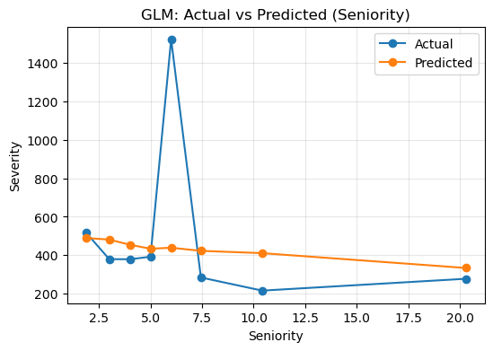

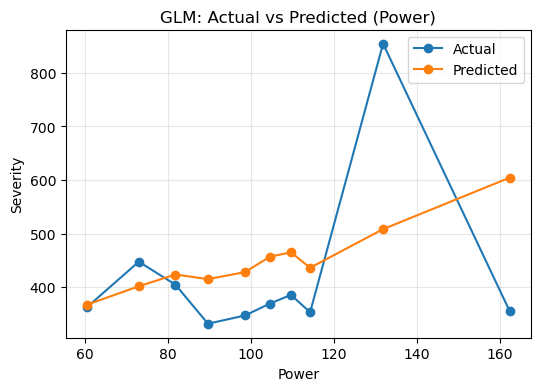

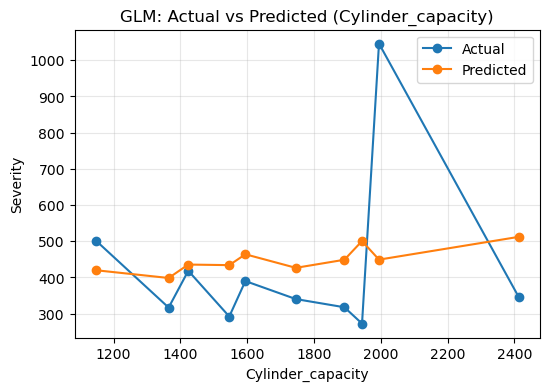

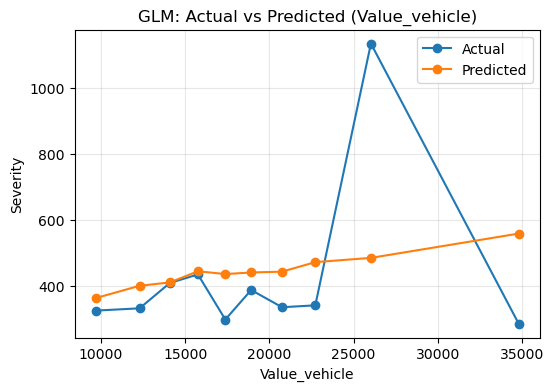

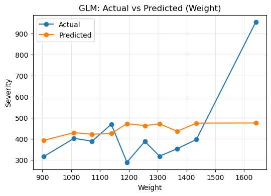

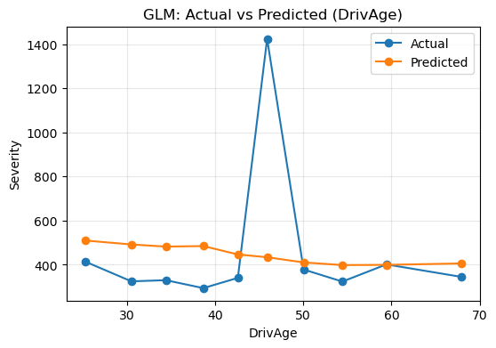

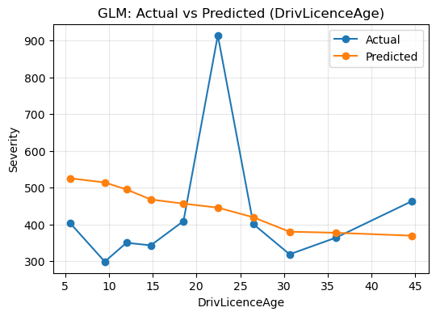

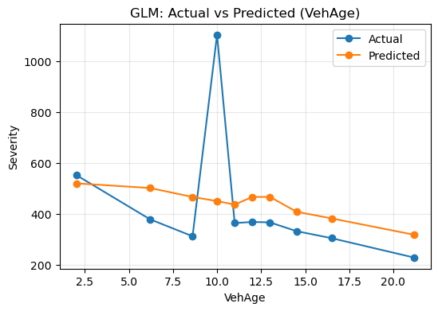

```python
# Validierungsdaten für Plot verwenden
plot_df = X_valid_sev_oh[top8_columns].copy()

plot_df["actual"] = y_valid_sev.values
plot_df["pred"] = pred_valid_glm_sev
plot_df["weight"] = w_valid_sev.values

for feature in top8_columns:

    df_plot = plot_df.copy()

    # kontinuierlich vs kategorisch unterscheiden

    df_plot["bin"] = pd.qcut(df_plot[feature], q=10, duplicates="drop")

    summary = df_plot.groupby("bin").apply(
            lambda g: pd.Series({
                "x": g[feature].mean(),
                "actual": np.average(g["actual"], weights=g["weight"]),
                "pred": np.average(g["pred"], weights=g["weight"])
            })
        ).reset_index()


    plt.figure(figsize=(6, 4))
    plt.plot(summary["x"], summary["actual"], marker="o", label="Actual")
    plt.plot(summary["x"], summary["pred"], marker="o", label="Predicted")

    plt.xlabel(feature)
    plt.ylabel("Severity")
    plt.title(f"GLM: Actual vs Predicted ({feature})")
    plt.legend()
    plt.grid(alpha=0.3)
    plt.show()
```

### Interpretation der Actual-vs.-Predicted-Plots für das Gamma-GLM

Die Plots zeigen, dass das Gamma-GLM die vorhergesagte **Severity** insgesamt deutlich glatter modelliert als die tatsächlich beobachteten Werte. Die Prognosen folgen eher einem stabilen Durchschnittstrend, während die tatsächlichen Schadenhöhen je nach Merkmalsausprägung stark schwanken.

Diese Ausschläge werden vom GLM nicht nachgebildet. Das ist plausibel, da Schadenhöhen typischerweise stark rechtsschief verteilt sind und einzelne Großschäden einzelne Gruppen stark beeinflussen können. Das GLM glättet solche Ausreißer und schätzt eher den erwarteten Durchschnittseffekt.

### Eignung der Gamma-Verteilung für das Severity-Modell

Die Gamma-Verteilung eignet sich besonders gut für die Modellierung von Schadenhöhen, da diese ausschließlich positive Werte annehmen und in der Praxis typischerweise rechtsschief verteilt sind. Große Schäden treten selten, aber mit hoher Intensität auf, während kleine Schäden häufiger vorkommen. Dieses Muster wird durch die Gamma-Verteilung gut abgebildet.

Ein weiterer wichtiger Aspekt ist die Beziehung zwischen Erwartungswert und Varianz. Bei der Gamma-Verteilung wächst die Varianz mit dem Erwartungswert, was in Versicherungsdaten häufig beobachtet wird. Risiken mit höheren erwarteten Schadenkosten weisen oft auch eine größere Streuung auf. In Kombination mit einer Log-Link-Funktion wird zudem sichergestellt, dass alle vorhergesagten Werte positiv sind und die Effekte der Prädiktoren multiplikativ interpretiert werden können.

##### Vor- und Nachteile im Vergleich zu alternativen Verteilungen

Die Gamma-Verteilung hat den Vorteil, dass sie sich gut in den GLM-Rahmen integrieren lässt und eine stabile sowie effiziente Schätzung ermöglicht. Die Interpretation der Koeffizienten ist durch die Log-Link-Funktion intuitiv, da sie als relative Änderungen verstanden werden können. Dadurch ist das Modell besonders gut für aktuarielle Anwendungen geeignet, bei denen Transparenz und Interpretierbarkeit eine wichtige Rolle spielen.

Ein Nachteil der Gamma-Verteilung besteht darin, dass sie extrem schwere Verteilungsschwänze nur eingeschränkt abbilden kann. In Datensätzen mit sehr großen Einzelschäden kann dies dazu führen, dass diese systematisch unterschätzt werden. Alternativ kann die Lognormalverteilung stärkere Schiefe und schwerere Tails modellieren, ist jedoch weniger direkt in den GLM-Rahmen integrierbar. Tweedie-Modelle bieten eine flexible Erweiterung, da sie sowohl Frequenz als auch Schadenhöhe gemeinsam modellieren können, sind jedoch komplexer in der Interpretation. Für die Modellierung extremer Schäden werden zudem häufig Heavy-Tail-Verteilungen wie Pareto verwendet, die jedoch meist separat im Tail-Bereich eingesetzt werden.

##### Bedeutung der Regularisierung im GLM-Kontext

Auch im Kontext von GLM-Modellen spielt Regularisierung eine wichtige Rolle, insbesondere bei vielen Prädiktoren oder bei stark korrelierten Variablen. Ohne Regularisierung können die geschätzten Koeffizienten instabil werden und empfindlich auf kleine Änderungen in den Daten reagieren. Dies führt zu Overfitting und einer schlechteren Generalisierungsfähigkeit auf neue Daten.

Regularisierungsmethoden wie Ridge- oder LASSO-Regularisierung wirken diesem Problem entgegen, indem sie große Koeffizienten bestrafen und das Modell glätten. Dadurch wird die Varianz reduziert und die Stabilität des Modells erhöht. Im vorliegenden Ansatz wurde die Komplexität des Modells bereits durch eine Feature-Selektion auf acht Prädiktoren eingeschränkt, was eine implizite Form der Regularisierung darstellt.

Insgesamt stellt Regularisierung einen wichtigen Mechanismus dar, um einen sinnvollen Kompromiss zwischen Modellflexibilität und Generalisierungsfähigkeit zu erreichen.

d) GAM (Generalized Additive Model)

Erstellen Sie ein Generalized Additive Model (GAM) auf Basis der gleichen Variablen wie in Teilaufgabe c). Speichern Sie die Ergebnisse. Plotten Sie die partiellen Abhängigkeiten (Splines) für die kontinuierlichen Merkmale Ihres GAM. Identifizieren Sie zwei Merkmale mit deutlichem nicht-linearem Verlauf und interpretieren Sie diese aus aktuarieller Sicht. Warum ist ein GAM häufig einem linearen GLM überlegen? Erstellen Sie im Anschluss eine Vergleichstabelle aller Severity-Modelle und kommentieren Sie das Ergebnis.

## **Lösung:**

### GAM Modell

```python
# Gleiche Variablen wie im Gamma-GLM
gam_features = top8_columns.copy()

X_train_gam = X_train_sev_oh[gam_features].copy()
X_valid_gam = X_valid_sev_oh[gam_features].copy()
X_test_gam  = X_test_sev_oh[gam_features].copy()

# Zielvariable
y_train_gam = y_train_sev.copy()
y_valid_gam = y_valid_sev.copy()
y_test_gam  = y_test_sev.copy()

# Gewichtung mit N_claims_year
w_train_gam = w_train_sev.copy()
w_valid_gam = w_valid_sev.copy()
w_test_gam  = w_test_sev.copy()

print("GAM Features:")
print(gam_features)
# Kontinuierliche Merkmale aus ursprünglichen numerischen Liste ohne Exposure

continuous_gam_features = [
    col for col in gam_features
    if col in var_num_sev and X_train_gam[col].nunique() > 10
]

linear_gam_features = [
    col for col in gam_features
    if col not in continuous_gam_features
]

print("Kontinuierliche Features mit Splines:")
print(continuous_gam_features)

print("Lineare / Dummy Features:")
print(linear_gam_features)
#GAM Terme definieren
terms = None

for i, feature in enumerate(gam_features):

    if feature in continuous_gam_features:
        term = s(i, n_splines=7)
    else:
        term = l(i)

    if terms is None:
        terms = term
    else:
        terms = terms + term
#Gamma - GAM trainieren
X_train_gam_np = X_train_gam.to_numpy()
X_valid_gam_np = X_valid_gam.to_numpy()
X_test_gam_np  = X_test_gam.to_numpy()

start_time = time.time()
gam_sev = GammaGAM(
    terms
).fit(
    X_train_gam_np,
    y_train_gam,
    weights=w_train_gam
)

fit_time_gam_sev = time.time() - start_time

print(gam_sev.summary())
print(f"Trainingszeit GAM: {fit_time_gam_sev:.4f} Sekunden")
```

```
GAM Features:
['Seniority', 'Power', 'Cylinder_capacity', 'Value_vehicle', 'Weight', 'DrivAge', 'DrivLicenceAge', 'VehAge']
Kontinuierliche Features mit Splines:
['Seniority', 'Power', 'Cylinder_capacity', 'Value_vehicle', 'Weight', 'DrivAge', 'DrivLicenceAge', 'VehAge']
Lineare / Dummy Features:
[]
GammaGAM
=============================================== ==========================================================
Distribution:                         GammaDist Effective DoF:                                     32.2968
Link Function:                          LogLink Log Likelihood:                                -22721.3278
Number of Samples:                         3131 AIC:                                            45509.2492
                                                AICc:                                           45509.9867
                                                GCV:                                                4.1218
                                                Scale:                                              3.6389
                                                Pseudo R-Squared:                                   0.0668
==========================================================================================================
Feature Function                  Lambda               Rank         EDoF         P > x        Sig. Code
================================= ==================== ============ ============ ============ ============
s(0)                              [0.6]                7            5.3          7.07e-02     .
s(1)                              [0.6]                7            4.4          9.39e-01
s(2)                              [0.6]                7            3.5          9.81e-01
s(3)                              [0.6]                7            2.8          9.82e-01
s(4)                              [0.6]                7            3.5          7.12e-01
s(5)                              [0.6]                7            4.3          4.97e-01
s(6)                              [0.6]                7            4.1          7.70e-02     .
s(7)                              [0.6]                7            4.3          4.81e-01
intercept                                              1            0.0          6.52e-05     ***
==========================================================================================================
Significance codes:  0 '***' 0.001 '**' 0.01 '*' 0.05 '.' 0.1 ' ' 1

WARNING: Fitting splines and a linear function to a feature introduces a model identifiability problem
         which can cause p-values to appear significant when they are not.

WARNING: p-values calculated in this manner behave correctly for un-penalized models or models with
         known smoothing parameters, but when smoothing parameters have been estimated, the p-values
         are typically lower than they should be, meaning that the tests reject the null too readily.
None
Trainingszeit GAM: 0.7545 Sekunden
```

```python
#Predictions & Evaluation
pred_train_gam_sev = np.clip(gam_sev.predict(X_train_gam_np), 1e-12, None)
pred_valid_gam_sev = np.clip(gam_sev.predict(X_valid_gam_np), 1e-12, None)
pred_test_gam_sev  = np.clip(gam_sev.predict(X_test_gam_np),  1e-12, None)

gam_sev_results = pd.DataFrame([{
    "model_name": "Gamma GAM",

    "gamma_dev_train": gamma_deviance(
        y_train_gam, pred_train_gam_sev, w_train_gam
    ),
    "gamma_dev_valid": gamma_deviance(
        y_valid_gam, pred_valid_gam_sev, w_valid_gam
    ),
    "gamma_dev_test": gamma_deviance(
        y_test_gam, pred_test_gam_sev, w_test_gam
    ),

    "mae_train": weighted_mae(
        y_train_gam, pred_train_gam_sev, w_train_gam
    ),
    "mae_valid": weighted_mae(
        y_valid_gam, pred_valid_gam_sev, w_valid_gam
    ),
    "mae_test": weighted_mae(
        y_test_gam, pred_test_gam_sev, w_test_gam
    ),

    "rmse_train": weighted_rmse(
        y_train_gam, pred_train_gam_sev, w_train_gam
    ),
    "rmse_valid": weighted_rmse(
        y_valid_gam, pred_valid_gam_sev, w_valid_gam
    ),
    "rmse_test": weighted_rmse(
        y_test_gam, pred_test_gam_sev, w_test_gam
    ),

    "fit_time_sec": fit_time_gam_sev
}])

display(gam_sev_results)


#Ergebnisse speichern
severity_results_df = pd.concat(
    [severity_results_df, gam_sev_results],
    ignore_index=True
)

display(severity_results_df)
```

|  | model_name | gamma_dev_train | gamma_dev_valid | gamma_dev_test | mae_train | mae_valid | mae_test | rmse_train | rmse_valid | rmse_test | fit_time_sec |
| --- | --- | --- | --- | --- | --- | --- | --- | --- | --- | --- | --- |
| 0 | Gamma GAM | 2.001477 | 2.214697 | 2.239564 | 474.366951 | 462.518691 | 608.377203 | 1297.993736 | 1832.854688 | 3496.128171 | 0.754507 |

|  | model_name | gamma_dev_train | gamma_dev_valid | gamma_dev_test | mae_train | mae_valid | mae_test | rmse_train | rmse_valid | rmse_test | fit_time_sec |
| --- | --- | --- | --- | --- | --- | --- | --- | --- | --- | --- | --- |
| 0 | Gamma GLM | 2.061578 | 2.099310 | 2.299499 | 478.886710 | 460.776438 | 616.403742 | 1305.546735 | 1826.633999 | 3502.221156 | NaN |
| 1 | Gamma GAM | 2.001477 | 2.214697 | 2.239564 | 474.366951 | 462.518691 | 608.377203 | 1297.993736 | 1832.854688 | 3496.128171 | 0.754507 |

```python
#GAM mit Regularisierung
terms = None

for i, feature in enumerate(gam_features):

    if feature in continuous_gam_features:
        term = s(i, n_splines=7) #wehiger Splines
    else:
        term = l(i)

    if terms is None:
        terms = term
    else:
        terms = terms + term

lam_grid = np.logspace(-2, 6, 17)

gam_lam_results = []


for lam in lam_grid:
    start_time = time.time()

    gam_tmp = GammaGAM(
        terms,
        lam=lam
    ).fit(
        X_train_gam_np,
        y_train_gam,
        weights=w_train_gam
    )

    fit_time = time.time() - start_time

    pred_train = np.clip(gam_tmp.predict(X_train_gam_np), 1e-12, None)
    pred_valid = np.clip(gam_tmp.predict(X_valid_gam_np), 1e-12, None)

    gamma_dev_train = gamma_deviance(
        y_train_gam,
        pred_train,
        w_train_gam
    )

    gamma_dev_valid = gamma_deviance(
        y_valid_gam,
        pred_valid,
        w_valid_gam
    )

    gam_lam_results.append({
        "lam": lam,
        "gamma_dev_train": gamma_dev_train,
        "gamma_dev_valid": gamma_dev_valid,
        "fit_time_sec": fit_time
    })

gam_lam_results_df = pd.DataFrame(gam_lam_results)
display(gam_lam_results_df.sort_values("gamma_dev_valid"))

#Das beste GAM Modell
best_lam = gam_lam_results_df.loc[
    gam_lam_results_df["gamma_dev_valid"].idxmin(),
    "lam"
]
print("Bestes lambda:", best_lam)
start_time = time.time()

gam_sev_reg = GammaGAM(
    terms,
    lam=best_lam
).fit(
    X_train_gam_np,
    y_train_gam,
    weights=w_train_gam
)

fit_time_gam_sev_reg = time.time() - start_time

print(gam_sev_reg.summary())
pred_train_gam_reg = np.clip(gam_sev_reg.predict(X_train_gam_np), 1e-12, None)
pred_valid_gam_reg = np.clip(gam_sev_reg.predict(X_valid_gam_np), 1e-12, None)
pred_test_gam_reg  = np.clip(gam_sev_reg.predict(X_test_gam_np),  1e-12, None)

gam_reg_results = pd.DataFrame([{
    "model_name": "Gamma GAM regularisiert",

    "gamma_dev_train": gamma_deviance(
        y_train_gam, pred_train_gam_reg, w_train_gam
    ),
    "gamma_dev_valid": gamma_deviance(
        y_valid_gam, pred_valid_gam_reg, w_valid_gam
    ),
    "gamma_dev_test": gamma_deviance(
        y_test_gam, pred_test_gam_reg, w_test_gam
    ),

    "mae_train": weighted_mae(
        y_train_gam, pred_train_gam_reg, w_train_gam
    ),
    "mae_valid": weighted_mae(
        y_valid_gam, pred_valid_gam_reg, w_valid_gam
    ),
    "mae_test": weighted_mae(
        y_test_gam, pred_test_gam_reg, w_test_gam
    ),

    "rmse_train": weighted_rmse(
        y_train_gam, pred_train_gam_reg, w_train_gam
    ),
    "rmse_valid": weighted_rmse(
        y_valid_gam, pred_valid_gam_reg, w_valid_gam
    ),
    "rmse_test": weighted_rmse(
        y_test_gam, pred_test_gam_reg, w_test_gam
    ),

    "fit_time_sec": fit_time_gam_sev_reg,
    "lambda": best_lam
}])

display(gam_reg_results)



#Ergebnisse speichern
severity_results_df = pd.concat(
    [severity_results_df, gam_reg_results],
    ignore_index=True
)
```

|  | lam | gamma_dev_train | gamma_dev_valid | fit_time_sec |
| --- | --- | --- | --- | --- |
| 16 | 1000000.000000 | 2.061568 | 2.099317 | 0.441696 |
| 15 | 316227.766017 | 2.061545 | 2.099331 | 0.343299 |
| 14 | 100000.000000 | 2.061475 | 2.099377 | 0.345309 |
| 13 | 31622.776602 | 2.061255 | 2.099519 | 0.332907 |
| 12 | 10000.000000 | 2.060597 | 2.099962 | 0.343227 |
| 11 | 3162.277660 | 2.058804 | 2.101296 | 0.329631 |
| 10 | 1000.000000 | 2.054968 | 2.104868 | 0.353097 |
| 9 | 316.227766 | 2.049441 | 2.111979 | 0.312039 |
| 8 | 100.000000 | 2.043373 | 2.121816 | 0.339896 |
| 7 | 31.622777 | 2.036149 | 2.134962 | 0.380060 |
| 6 | 10.000000 | 2.026587 | 2.154192 | 0.518835 |
| 5 | 3.162278 | 2.015231 | 2.177580 | 0.519785 |
| 4 | 1.000000 | 2.005058 | 2.202736 | 0.600325 |
| 3 | 0.316228 | 1.997687 | 2.230473 | 0.707334 |
| 2 | 0.100000 | 1.992752 | 2.259258 | 0.901543 |
| 1 | 0.031623 | 1.990040 | 2.282941 | 1.058850 |
| 0 | 0.010000 | 1.988645 | 2.298057 | 1.352643 |

```
Bestes lambda: 1000000.0
GammaGAM
=============================================== ==========================================================
Distribution:                         GammaDist Effective DoF:                                      9.0014
Link Function:                          LogLink Log Likelihood:                                -22804.4154
Number of Samples:                         3131 AIC:                                            45628.8335
                                                AICc:                                            45628.904
                                                GCV:                                                4.1572
                                                Scale:                                              3.9811
                                                Pseudo R-Squared:                                   0.0388
==========================================================================================================
Feature Function                  Lambda               Rank         EDoF         P > x        Sig. Code
================================= ==================== ============ ============ ============ ============
s(0)                              [1000000.]           7            2.0          3.31e-02     *
s(1)                              [1000000.]           7            1.2          9.69e-01
s(2)                              [1000000.]           7            1.0          9.06e-01
s(3)                              [1000000.]           7            1.1          8.51e-01
s(4)                              [1000000.]           7            0.8          5.49e-01
s(5)                              [1000000.]           7            1.0          3.62e-01
s(6)                              [1000000.]           7            1.0          4.76e-02     *
s(7)                              [1000000.]           7            0.9          6.83e-01
intercept                                              1            0.0          1.11e-16     ***
==========================================================================================================
Significance codes:  0 '***' 0.001 '**' 0.01 '*' 0.05 '.' 0.1 ' ' 1

WARNING: Fitting splines and a linear function to a feature introduces a model identifiability problem
         which can cause p-values to appear significant when they are not.

WARNING: p-values calculated in this manner behave correctly for un-penalized models or models with
         known smoothing parameters, but when smoothing parameters have been estimated, the p-values
         are typically lower than they should be, meaning that the tests reject the null too readily.
None
```

|  | model_name | gamma_dev_train | gamma_dev_valid | gamma_dev_test | mae_train | mae_valid | mae_test | rmse_train | rmse_valid | rmse_test | fit_time_sec | lambda |
| --- | --- | --- | --- | --- | --- | --- | --- | --- | --- | --- | --- | --- |
| 0 | Gamma GAM regularisiert | 2.061568 | 2.099317 | 2.299464 | 478.885508 | 460.774862 | 616.401659 | 1305.546083 | 1826.634817 | 3502.218496 | 0.449863 | 1000000.000000 |

In der Lambda-Suche wurde die beste Validierungsperformance bei sehr hoher Regularisierung erreicht. Dies zeigt, dass zusätzliche Flexibilität der Splines auf den Validierungsdaten keinen stabilen Nutzen liefert. Das regularisierte GAM nähert sich dadurch einem stark geglätteten bzw. nahezu linearen Modell an.

Dieses Ergebnis passt zur Evaluation, in der das lineare Gamma-GLM auf dem Validierungsdatensatz besser abschneidet als das unregularisierte GAM. Die Severity-Daten enthalten wenige positive Schadenbeobachtungen und starke Ausreißer, wodurch flexible Splines leicht instabil werden. Eine starke Regularisierung reduziert diese Instabilität und verbessert die Generalisierung.

#### Splines (nicht regularisiertes GAM)

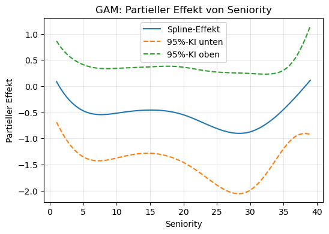

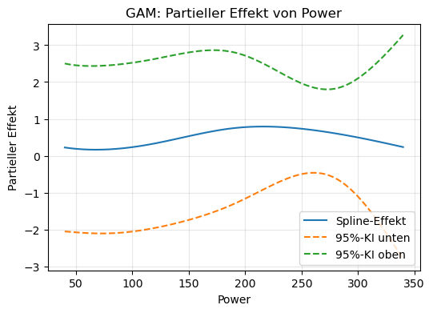

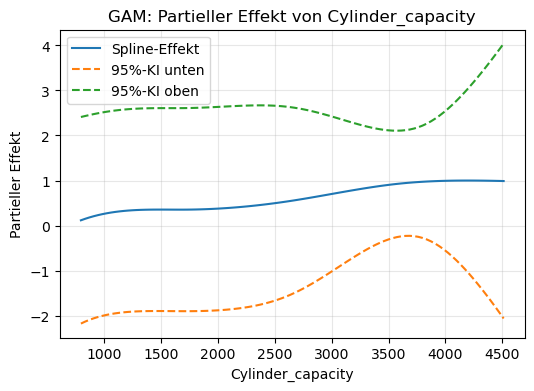

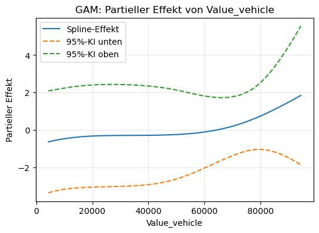

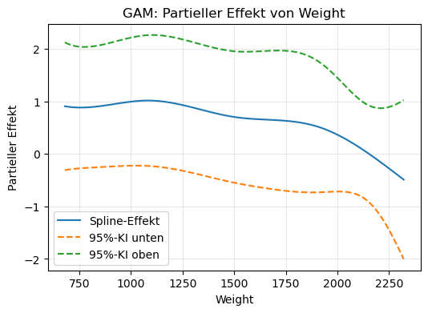

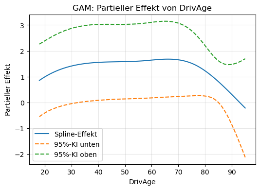

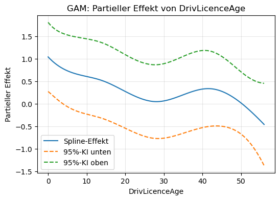

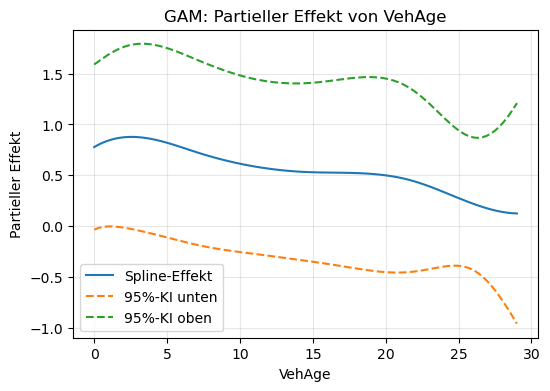

```python
# kontinuierliche Features im GAM
for feature in continuous_gam_features:

    # Position des Features in der GAM-Matrix
    i = gam_features.index(feature)

    XX = gam_sev.generate_X_grid(term=i)

    pdep, confi = gam_sev.partial_dependence(
        term=i,
        X=XX,
        width=0.95
    )

    plt.figure(figsize=(6, 4))

    plt.plot(
        XX[:, i],
        pdep,
        label="Spline-Effekt"
    )

    plt.plot(
        XX[:, i],
        confi[:, 0],
        linestyle="--",
        label="95%-KI unten"
    )

    plt.plot(
        XX[:, i],
        confi[:, 1],
        linestyle="--",
        label="95%-KI oben"
    )

    plt.xlabel(feature)
    plt.ylabel("Partieller Effekt")
    plt.title(f"GAM: Partieller Effekt von {feature}")
    plt.legend()
    plt.grid(alpha=0.3)
    plt.show()
```

#### Interpretation der partiellen Abhängigkeiten des GAM: Identifizieren Sie zwei Merkmale mit deutlichem nicht-linearem Verlauf und interpretieren Sie diese aus aktuarieller Sicht.

Die partiellen Abhängigkeitsplots zeigen den geschätzten Einfluss der kontinuierlichen Merkmale auf die erwartete Severity. Da ein Gamma-GAM mit Log-Link verwendet wurde, sind die partiellen Effekte auf der Link-Skala zu interpretieren. Positive Werte erhöhen die erwartete Schadenhöhe relativ, negative Werte senken sie relativ. Die gestrichelten Linien zeigen die 95%-Konfidenzintervalle.

Insgesamt zeigen die Splines, dass mehrere Merkmale keinen rein linearen Zusammenhang mit der durchschnittlichen Schadenhöhe aufweisen. Dies bestätigt grundsätzlich die Motivation für ein GAM, da es nichtlineare Effekte flexibler abbilden kann als ein klassisches GLM. Allerdings sind die Konfidenzintervalle teilweise sehr breit, insbesondere an den Randbereichen der Variablen. Das deutet darauf hin, dass dort weniger Beobachtungen vorliegen und die geschätzten Effekte unsicherer sind.

Bei `Seniority` ist ein deutlich nichtlinearer Verlauf erkennbar. Der Effekt fällt zunächst stark ab, bleibt im mittleren Bereich relativ niedrig und steigt bei sehr hoher Seniority wieder an. Fachlich kann dies darauf hindeuten, dass die Schadenhöhe bei sehr neuen Kunden höher ist, bei mittlerer Vertragsdauer niedriger ausfällt und bei sehr langjährigen Kunden wieder ansteigt. Der Anstieg am rechten Rand sollte jedoch vorsichtig interpretiert werden, da die Unsicherheit dort deutlich zunimmt.

Auch `DrivAge` zeigt einen ausgeprägt nichtlinearen Verlauf. Der Effekt steigt bis etwa zum mittleren Fahreralter an und fällt danach wieder ab. Dies deutet darauf hin, dass die Severity nicht konstant linear mit dem Fahreralter zunimmt oder abnimmt. Aus aktuarieller Sicht kann dies plausibel sein, da unterschiedliche Altersgruppen unterschiedliche Fahrzeugnutzung, Fahrzeugwerte, Stornoverhalten oder Schadenarten aufweisen können.

#### Warum ist ein GAM häufig einem linearen GLM überlegen?

Ein lineares GLM nimmt an, dass der Effekt jedes Prädiktors auf der Link-Skala linear ist. Im Gamma-GLM mit Log-Link bedeutet das beispielsweise, dass eine Erhöhung eines numerischen Merkmals immer denselben proportionalen Effekt auf die erwartete Severity hat.

Ein GAM erweitert diese Struktur, indem kontinuierliche Merkmale durch glatte Funktionen, sogenannte Splines, modelliert werden. Dadurch muss der Zusammenhang zwischen einem Merkmal und der Zielvariable nicht vorher als linear angenommen werden. Das Modell kann z. B. Schwellenwerte, Plateaus, U-förmige Verläufe oder abnehmende bzw. zunehmende Grenzwirkungen erfassen.

Das ist in der aktuariellen Modellierung besonders relevant, weil viele Risikofaktoren nichtlinear wirken. Dies haben auch die obige Plots für die Merkmale `Seniority` und z.B. `DrivAge` gezeigt.

Gleichzeitig bleibt ein GAM deutlich interpretierbarer als viele Black-Box-Modelle, da die partiellen Effekte der einzelnen Merkmale grafisch dargestellt und fachlich beurteilt werden können. Damit verbindet ein GAM die Transparenz eines GLM mit einer höheren Flexibilität bei nichtlinearen Zusammenhängen.

Ein GAM ist daher einem linearen GLM häufig überlegen, wenn die tatsächlichen Zusammenhänge zwischen Prädiktoren und Zielgröße nicht linear sind. Allerdings kann die zusätzliche Flexibilität auch zu Overfitting führen, insbesondere bei kleinen Datensätzen oder stark verrauschten Schadenhöhen. Deshalb ist eine angemessene Regularisierung der Splines wichtig.

#### Vergleich Gamma-GLM und Gamma-GAM (nicht regulasiert)

```python
display(severity_results_df)
```

|  | model_name | gamma_dev_train | gamma_dev_valid | gamma_dev_test | mae_train | mae_valid | mae_test | rmse_train | rmse_valid | rmse_test | fit_time_sec | lambda |
| --- | --- | --- | --- | --- | --- | --- | --- | --- | --- | --- | --- | --- |
| 0 | Gamma GLM | 2.061578 | 2.099310 | 2.299499 | 478.886710 | 460.776438 | 616.403742 | 1305.546735 | 1826.633999 | 3502.221156 | NaN | NaN |
| 1 | Gamma GAM | 2.001477 | 2.214697 | 2.239564 | 474.366951 | 462.518691 | 608.377203 | 1297.993736 | 1832.854688 | 3496.128171 | 0.754507 | NaN |
| 2 | Gamma GAM regularisiert | 2.061568 | 2.099317 | 2.299464 | 478.885508 | 460.774862 | 616.401659 | 1305.546083 | 1826.634817 | 3502.218496 | 0.449863 | 1000000.000000 |

Die Evaluation zeigt, dass das Gamma-GAM nicht eindeutig besser ist als das Gamma-GLM. Auf dem Trainingsdatensatz erzielt das GAM eine niedrigere Gamma-Deviance als das GLM (2.001 gegenüber 2.061). Dies ist erwartungsgemäß, da das GAM durch Splines flexibler ist und nichtlineare Zusammenhänge besser an die Trainingsdaten anpassen kann.

Auf dem Testdatensatz ist das GAM dagegen leicht besser als das GLM (2.240 gegenüber 2.299). Auch die RMSE und MAE ist beim GAM minimal niedriger als beim GLM. Insgesamt zeigt sich daher kein klarer, stabiler Vorteil des GAM über alle Datensätze hinweg.

Die Ergebnisse sprechen dafür, dass das GAM zwar einzelne nichtlineare Effekte besser modellieren kann, diese zusätzliche Flexibilität aber nicht durchgehend robust ist. Die starke Verschlechterung auf dem Validierungsdatensatz zeigt, dass die nichtlinearen Strukturen möglicherweise zu stark an die Trainingsdaten angepasst wurden oder dass die Validierungsdaten eine andere Schadenstruktur enthalten.

Ein weiterer Grund kann die geringe Anzahl positiver Schadenbeobachtungen sein. Severity-Modelle werden nur auf Policen mit Schäden trainiert. Dadurch ist die Datenbasis deutlich kleiner als beim Frequency-Modell. Flexible Modelle wie GAMs benötigen jedoch ausreichend viele Beobachtungen, um stabile nichtlineare Effekte zu schätzen. Bei wenigen Beobachtungen können Splines stark von einzelnen Ausreißern beeinflusst werden.

Zudem sind Schadenhöhen typischerweise stark rechtsschief und enthalten extreme Ausreißer. Solche Extremwerte können die geschätzten Splines beeinflussen und zu instabilen Verläufen führen. Das GLM ist aufgrund seiner linearen Struktur robuster, während das GAM empfindlicher auf lokale Muster reagieren kann.

Zusammenfassend das GAM zeigt eine bessere Anpassung auf den Trainingsdaten, jedoch eine schlechtere Validierungsperformance als das GLM. Dies deutet darauf hin, dass die zusätzliche Flexibilität der Splines nicht stabil generalisiert und teilweise zu Overfitting führt. Da die Testperformance nur leicht besser ist, aber die Validierungsleistung deutlich schlechter ausfällt, ist das GAM nicht eindeutig überlegen. Das GLM bleibt in diesem Fall das robustere und interpretierbarere Modell.

B4: Modellierung des Schadenbedarfs

*[Lernziele: 2.1, 2.2, 3.4 & 5.1 | Punkte: 29]*  
Ziel dieser Aufgabe ist die direkte Schätzung des erwarteten Schadenbedarfs pro Police (Pure Premium), d. h. Cost_claims_year / Exposure. Dies kann entweder durch Multiplikation der besten Frequency- und Severity- Modelle (Produktmodell) oder durch direkte Tweedie-Regression erfolgen. Referenzen: [3] https://scikit-learn.org/stable/auto_examples/linear_model/plot_tweedie_regression_insurance_claims.html [4] https://www.casact.org/sites/default/files/2021-01/05-Goldburd-Khare-Tevet.pdf

a)Produktmodell: Frequency × Severity

Kombinieren Sie das jeweils beste Frequency und Severity- Modell zu einem Produktmodell. Berechnen Sie anschließend die Produktprognose (Frequency × Severity) und evaluieren Sie das Modell mit Tweedie Deviance. Fügen Sie die Ergebnisse einer geeigneten Ergebnisstruktur hinzu. Diskutieren Sie, welche Vor- und Nachteile das Produktmodell im Vergleich zu einer direkten Modellierung hat.

## **Lösung:**

Ich vermute, dass die Evaluation der Modelle für Schadenbedarf auf dem Testdatensatz erwünscht ist (analog zu der Teilaufgabe B2d).

Das Gamma-GAM Modell wurde nur auf Datensätzen mit mindestens einem Schaden trainiert. Für das Produktmodell für Schadenbedarfprognose brauchen wir aber eine Severity-Prognose für alle Beobachtungen in Train, Valid und Test.

Hier wird als Evaluationsmetrik die gewichtete Tweedie-Deviance berechnet. Die Gewichtung erfolgt über die `Exposure`, sodass Verträge mit längerer Beobachtungsdauer entsprechend stärker berücksichtigt werden. Der Parameter `power` steuert die angenommene Verteilung innerhalb der Tweedie-Familie. Der verwendete Standardwert für `power` wird aus der Referenz [3] übernommen und dient als fachlich begründete Einstellung für die Modellbewertung.

```python
# ============================================================
# Tweedie Deviance
# ============================================================

def w_tweedie_deviance(y_true, y_pred, power=1.9, weights=None, eps=1e-12):
    """
    Gewichtete Tweedie Deviance.

    Für aggregierte Schadenaufwände ist meist 1 < power < 2 sinnvoll.
    power = 1 entspricht Poisson,
    power = 2 entspricht Gamma.
    """

    y_true = np.asarray(y_true, dtype=float)
    y_pred = np.asarray(y_pred, dtype=float)

    y_true = np.clip(y_true, 0, None)
    y_pred = np.clip(y_pred, eps, None)

    if weights is None:
        weights = np.ones_like(y_true)
    else:
        weights = np.asarray(weights, dtype=float)

    p = power

    if p == 0:
        dev = (y_true - y_pred) ** 2

    elif p == 1:
        y_true_safe = np.clip(y_true, eps, None)
        dev = 2 * (y_true * np.log(y_true_safe / y_pred) - y_true + y_pred)
        dev[y_true == 0] = 2 * y_pred[y_true == 0]

    elif p == 2:
        y_true_safe = np.clip(y_true, eps, None)
        dev = 2 * ((y_true - y_pred) / y_pred - np.log(y_true_safe / y_pred))

    else:
        dev = 2 * (
            np.power(y_true, 2 - p) / ((1 - p) * (2 - p))
            - y_true * np.power(y_pred, 1 - p) / (1 - p)
            + np.power(y_pred, 2 - p) / (2 - p)
        )

    return np.sum(weights * dev) / np.sum(weights)
```

```python
# ============================================================
# B4a) Produktmodell: Frequency × Severity
# Bestes Frequency-Modell: LightGBM
# Bestes Severity-Modell: Gamma GAM
# ============================================================

# Produktmodell:
# Erwarteter Schadenbedarf = erwartete Schadenanzahl × erwartete durch. Schadenhöhe
# E[Cost_claims_year] = E[N_claims_year] × E[Severity]

model_name_product = "Produkt: LightGBM × Gamma GAM"

# ============================================================
# Severity-Designmatrizen für alle Beobachtungen erstellen
# ============================================================

def prepare_gam_product_matrix(df_original, var_cat_sev, gam_features):
    """
    Erstellt die Designmatrix für das trainierte Gamma-GAM
    für beliebige Daten, also auch für Policen ohne Schaden.
    """

    df = df_original.copy()

    # Spalten entfernen, die nicht als Severity-Features verwendet werden sollen
    drop_cols = [
        "Cost_claims_year",
        "Severity",
        "Premium",
        "Exposure",
        "N_claims_year"
    ]

    df = df.drop(columns=[col for col in drop_cols if col in df.columns])

    # One-Hot-Encoding wie beim Severity-Modell
    df_oh = pd.get_dummies(
        df,
        columns=[col for col in var_cat_sev if col in df.columns],
        drop_first=True
    )

    # Auf exakt die Features des trainierten Gamma-GAM bringen
    df_oh = df_oh.reindex(columns=gam_features, fill_value=0)

    return df_oh.astype("float32")
# Designmatrizen für alle Train-/Valid-/Test-Beobachtungen
X_train_gam_product = prepare_gam_product_matrix(
    train_original,
    var_cat_sev,
    gam_features
)

X_valid_gam_product = prepare_gam_product_matrix(
    valid_original,
    var_cat_sev,
    gam_features
)

X_test_gam_product = prepare_gam_product_matrix(
    test_original,
    var_cat_sev,
    gam_features
)

print("X_train_gam_product:", X_train_gam_product.shape)
print("X_valid_gam_product:", X_valid_gam_product.shape)
print("X_test_gam_product:", X_test_gam_product.shape)
print(X_train_gam_product.head())
```

```
X_train_gam_product: (9524, 8)
X_valid_gam_product: (3175, 8)
X_test_gam_product: (3175, 8)
       Seniority      Power  Cylinder_capacity  Value_vehicle      Weight  \
15072   3.000000 150.000000        1970.000000   22000.000000 1250.000000
3303   18.000000 110.000000        2184.000000   17949.000000 1260.000000
5502    3.000000 112.000000        2184.000000   22800.000000 1420.000000
9672    7.000000 105.000000        1896.000000   22000.000000 1251.000000
1048    3.000000 110.000000        1560.000000   20580.000000 1205.000000

        DrivAge  DrivLicenceAge    VehAge
15072 41.000000       10.000000 13.000000
3303  46.000000       25.000000 15.000000
5502  68.000000       28.000000 12.000000
9672  32.000000       13.000000 11.000000
1048  71.000000       52.000000 10.000000
```

```python
# ============================================================
# Severity-Prognosen mit Gamma GAM
# ============================================================

pred_train_sev_product = np.clip(
    gam_sev.predict(X_train_gam_product.to_numpy()),
    1e-12,
    None
)

pred_valid_sev_product = np.clip(
    gam_sev.predict(X_valid_gam_product.to_numpy()),
    1e-12,
    None
)

pred_test_sev_product = np.clip(
    gam_sev.predict(X_test_gam_product.to_numpy()),
    1e-12,
    None
)

print("Severity Train:", pred_train_sev_product.shape)
print("Severity Valid:", pred_valid_sev_product.shape)
print("Severity Test:", pred_test_sev_product.shape)
# pred_train_cann aus B1f)
# pred_valid_cann aus B1f)
# pred_test_cann aus B2d)
# ============================================================
# Frequency-Prognosen mit LightGBM -schon vorhanden
# ============================================================
pred_train_freq_product = np.clip(freq_pred_train_lgb, 1e-12, None)
pred_valid_freq_product = np.clip(freq_pred_valid_lgb, 1e-12, None)
pred_test_freq_product  = np.clip(freq_pred_test_lgb,  1e-12, None)

print("Frequency Train:", pred_train_freq_product.shape)
print("Frequency Valid:", pred_valid_freq_product.shape)
print("Frequency Test:", pred_test_freq_product.shape)
# ============================================================
# Produktprognose: Frequency × Severity
# ============================================================

pred_train_product = pred_train_freq_product * pred_train_sev_product
pred_valid_product = pred_valid_freq_product * pred_valid_sev_product
pred_test_product  = pred_test_freq_product  * pred_test_sev_product

pred_train_product = np.clip(pred_train_product, 1e-12, None)
pred_valid_product = np.clip(pred_valid_product, 1e-12, None)
pred_test_product  = np.clip(pred_test_product,  1e-12, None)

print("Produktprognose Train:", pred_train_product.shape)
print("Produktprognose Valid:", pred_valid_product.shape)
print("Produktprognose Test:", pred_test_product.shape)
```

```
Severity Train: (9524,)
Severity Valid: (3175,)
Severity Test: (3175,)
Frequency Train: (9524,)
Frequency Valid: (3175,)
Frequency Test: (3175,)
Produktprognose Train: (9524,)
Produktprognose Valid: (3175,)
Produktprognose Test: (3175,)
```

```python
# ============================================================
# Zielvariable: aggregierte Schadenhöhe: Cost_claims_year
# ============================================================

y_train_product = train_original["Cost_claims_year"].to_numpy(dtype="float32")
y_valid_product = valid_original["Cost_claims_year"].to_numpy(dtype="float32")
y_test_product  = test_original["Cost_claims_year"].to_numpy(dtype="float32")

exposure_train_product = train_original["Exposure"].to_numpy(dtype="float32")
exposure_valid_product = valid_original["Exposure"].to_numpy(dtype="float32")
exposure_test_product  = test_original["Exposure"].to_numpy(dtype="float32")
```

```python
# ============================================================
# Evaluation mit Tweedie Deviance
# ============================================================

tweedie_power = 1.9
fit_time_lgb = model_results_df.loc[
    model_results_df["model_name"] == "LightGBM",
    "fit_time_sec"
].iloc[0]

fit_time_gamma_gam = severity_results_df.loc[
    severity_results_df["model_name"] == "Gamma GAM",
    "fit_time_sec"
].iloc[0]

fit_time_product = fit_time_lgb + fit_time_gamma_gam
opt_time_product= opt_time_lgb

product_model_results = pd.DataFrame([{
    "model_name": model_name_product,

    "tweedie_power": tweedie_power,

    "tdw_train": w_tweedie_deviance(
        y_train_product,
        pred_train_product,
        power=tweedie_power,
        weights=exposure_train_product
    ),

    "tdw_valid": w_tweedie_deviance(
        y_valid_product,
        pred_valid_product,
        power=tweedie_power,
        weights=exposure_valid_product
    ),

    "tdw_test": w_tweedie_deviance(
        y_test_product,
        pred_test_product,
        power=tweedie_power,
        weights=exposure_test_product
    ),
     "opt_time_sec":opt_time_product,
    "fit_time_sec":fit_time_product,
    "notes": "Frequency_Model=LightGBM,Severity_model=Gamma GAM"
}])

display(product_model_results)
```

|  | model_name | tweedie_power | tdw_train | tdw_valid | tdw_test | opt_time_sec | fit_time_sec | notes |
| --- | --- | --- | --- | --- | --- | --- | --- | --- |
| 0 | Produkt: LightGBM × Gamma GAM | 1.900000 | 25.412106 | 26.110841 | 26.001551 | 59.133909 | 1.505707 | Frequency_Model=LightGBM,Severity_model=Gamma GAM |

```python
# ============================================================
# Ergebnisstruktur erweitern
# ============================================================
pure_premium_results_df = pd.DataFrame(columns=[
    "model_name",
    "tweedie_power",
    "tdw_train",
    "tdw_valid",
    "tdw_test",
     "opt_time_sec",
    "fit_time_sec",
    "notes"
])
try:
    pure_premium_results_df = pd.concat(
        [pure_premium_results_df, product_model_results],
        ignore_index=True
    )
except NameError:
     pure_premium_results_df = product_model_results.copy()

display(pure_premium_results_df)
```

|  | model_name | tweedie_power | tdw_train | tdw_valid | tdw_test | opt_time_sec | fit_time_sec | notes |
| --- | --- | --- | --- | --- | --- | --- | --- | --- |
| 0 | Produkt: LightGBM × Gamma GAM | 1.900000 | 25.412106 | 26.110841 | 26.001551 | 59.133909 | 1.505707 | Frequency_Model=LightGBM,Severity_model=Gamma GAM |

### Diskussion: Produktmodell vs. direkte Modellierung

Im Produktmodell wird der erwartete Schadenbedarf, also die **Pure Premium**, nicht direkt modelliert, sondern aus zwei separaten Teilmodellen zusammengesetzt. Zunächst wird ein Frequency-Modell für die erwartete Schadenhäufigkeit geschätzt. Anschließend wird ein Severity-Modell für die erwartete durchschnittliche Schadenhöhe pro Schaden verwendet.

Mathematisch lässt sich die Pure Premium einer Police $i$ als Produkt aus erwarteter Schadenhäufigkeit und erwarteter Schadenhöhe darstellen:

$$ \widehat{\text{PurePremium}}_i = \widehat{\mathbb{E}}\left(\frac{N_i}{\text{Exposure}_i} \mid X_i\right) \cdot \widehat{\mathbb{E}}\left(Y_i \mid X_i, N_i > 0\right) $$

Dabei bezeichnet $N_i$ die Anzahl der Schäden der Police $i$, $Y_i$ die durchschnittliche Schadenhöhe pro Schaden und $X_i$ die erklärenden Merkmale. Die Frequency-Komponente beschreibt somit die erwartete Schadenanzahl pro Exposure-Einheit, während die Severity-Komponente die erwartete Schadenhöhe pro Schaden beschreibt.

Im konkreten Modell ergibt sich damit:

$$ \widehat{\text{PurePremium}}_i = \widehat{\text{Frequency}}_i^{\text{LightGBM}} \cdot \widehat{\text{Severity}}_i^{\text{Gamma-GAM}} $$

Das Frequency-Modell LightGBM liefert also eine Prognose für die erwartete Schadenhäufigkeit. Das Severity-Modell Gamma-GAM liefert eine Prognose für die erwartete Schadenhöhe pro Schaden. Durch Multiplikation beider Prognosen entsteht die Produktprognose für den erwarteten Schadenbedarf beziehungsweise die Pure Premium.

#### Vorteile des Produktmodells

Ein Vorteil dieses Ansatzes ist die gute aktuariell-fachliche Interpretierbarkeit. Schadenhäufigkeit und Schadenhöhe werden getrennt modelliert, was sinnvoll ist, da beide Größen unterschiedliche statistische Eigenschaften haben und durch unterschiedliche Merkmale beeinflusst werden können. So kann ein Merkmal beispielsweise stark auf die Schadenanzahl wirken, aber nur schwach auf die Schadenhöhe. Durch die getrennte Modellierung lässt sich besser nachvollziehen, ob ein bestimmter Effekt aus der Frequency- oder aus der Severity-Komponente stammt.

Ein weiterer Vorteil besteht darin, dass für Frequency und Severity jeweils ein speziell geeignetes Modell verwendet werden kann. In diesem Fall wird für die Schadenhäufigkeit ein LightGBM verwendet, während für die Schadenhöhe ein Gamma-GAM eingesetzt wird. Das Produktmodell kombiniert somit die Stärken beider Modellklassen.

Zudem entspricht das Produktmodell der klassischen aktuariellen Zerlegung des erwarteten Schadenbedarfs:

$$ \text{Pure Premium} = \text{Frequency} \cdot \text{Severity} $$

Diese Zerlegung ist fachlich gut nachvollziehbar und ermöglicht eine separate Analyse der beiden zentralen Schadenkomponenten.

#### Nachteile des Produktmodells

Nachteilig ist jedoch, dass sich Fehler aus beiden Teilmodellen auf die finale Produktprognose übertragen. Ist entweder die Frequency-Prognose oder die Severity-Prognose verzerrt, wirkt sich dies direkt auf die Schätzung der Pure Premium aus. Zusätzlich können sich Fehler durch die Multiplikation gegenseitig verstärken.

Ein weiterer Nachteil ist, dass mögliche Abhängigkeiten zwischen Schadenhäufigkeit und Schadenhöhe nicht direkt gemeinsam modelliert werden. Das Produktmodell behandelt beide Komponenten separat und kombiniert sie erst nachträglich. Falls Policen mit hoher Schadenhäufigkeit systematisch auch andere Schadenhöhen aufweisen, kann eine direkte gemeinsame Modellierung des Gesamtschadenbedarfs vorteilhaft sein.

Außerdem wird das Produktmodell nicht unmittelbar auf die finale Zielgröße optimiert. Frequency- und Severity-Modell werden jeweils mit eigenen Zielgrößen trainiert. Die resultierende Pure-Premium-Prognose ist daher nur indirekt optimiert. Es kann also vorkommen, dass die Teilmodelle einzeln gute Ergebnisse liefern, das Produkt jedoch in Bezug auf die Tweedie Deviance weniger optimal ist.

#### Direkte Modellierung

Bei einer direkten Modellierung wird die Pure Premium unmittelbar als Zielvariable verwendet. Das Modell schätzt also direkt:

$$ \widehat{\mathbb{E}}\left( \frac{\text{Cost_claims_year}_i}{\text{Exposure}_i} \mid X_i \right) $$

Ein Beispiel hierfür ist ein Tweedie-GLM. Dieses ist besonders für Versicherungsschäden geeignet, da Schadenbedarfe häufig nichtnegativ, rechtsschief verteilt und durch viele Nullbeobachtungen geprägt sind. Im Bereich $1 < p < 2$ kann die Tweedie-Verteilung sowohl die Masse bei null als auch die stetige positive Schadenhöhe abbilden.

Der Vorteil einer direkten Modellierung besteht darin, dass genau die Zielgröße optimiert wird, die später auch bewertet wird: der erwartete Schadenbedarf pro Exposure-Einheit. Dadurch ist das Modell direkt auf die Pure Premium ausgerichtet und kann unmittelbar mit der Tweedie Deviance bewertet werden.

Ein Nachteil ist jedoch, dass die direkte Modellierung weniger komponentenorientiert ist. Sie zeigt nicht separat, ob ein Effekt aus einer erhöhten Schadenhäufigkeit oder aus einer erhöhten Schadenhöhe stammt. Dadurch kann die fachliche Interpretation schwieriger sein als beim Produktmodell.

#### Vergleich beider Ansätze

Im Vergleich zur direkten Modellierung ist das Produktmodell stärker komponentenorientiert. Es ist besser interpretierbar und entspricht der klassischen aktuariellen Denkweise, bei der der erwartete Schadenbedarf als Produkt aus Schadenhäufigkeit und durchschnittlicher Schadenhöhe verstanden wird.

Die direkte Modellierung kann hingegen bei der reinen Prognosegüte Vorteile haben, da sie die Pure Premium unmittelbar optimiert. Sie vermeidet außerdem, dass zwei separat geschätzte Modelle nachträglich kombiniert werden müssen. Allerdings ist sie oft weniger transparent, da sie nicht getrennt zeigt, ob ein bestimmter Effekt aus der Frequency- oder aus der Severity-Komponente stammt.

Zusammenfassend bietet das Produktmodell eine hohe fachliche Interpretierbarkeit und ermöglicht eine getrennte Analyse von Schadenanzahl und Schadenhöhe. Die direkte Tweedie-Modellierung hat dagegen den Vorteil, dass sie den erwarteten Schadenbedarf pro Exposure-Einheit unmittelbar modelliert und direkt auf die finale Zielgröße optimiert. Welcher Ansatz vorzuziehen ist, hängt daher davon ab, ob der Fokus stärker auf aktuarieller Nachvollziehbarkeit oder auf direkter Optimierung der Gesamtprognose liegt.

b) Allgemeine Fragen zu Tweedie Modellen, GLM – Tweedie-Regressor mit Hyperparameter-Tuning

Erläutern Sie die Tweedie-Verteilung als Exponentialfamilie mit Power-Parameter (p). Welche bekannten Verteilungen erhält man für p = 0, 1, 2, 3? Welche Werte sind für Schadenbedarf-Modelle typischerweise relevant und warum? Wie lässt sich der Zusammenhang zwischen μ, ϕ und p zur Einschätzung der Modellgüte nutzen? Berechnen und interpretieren Sie den Dispersion-Parameter des Tweedie-Modells. Schätzen Sie ein GLM mit Tweedie-Verlustfunktion (TweedieRegressor). Führen Sie einen Grid Search über die Hyperparameter alpha und power durch. Geben Sie die besten Parameter und die Tweedie Deviance aus und fügen Sie sowohl das Baseline-Modell als auch das optimierte Modell der Ergebnisstruktur hinzu.

## **Lösung:**

### Allgemeine Fragen zu Tweedie Modelle

Die Tweedie-Verteilung gehört zur Klasse der Exponentialfamilien. Sie ist besonders flexibel, da ihre Varianz über einen Power-Parameter (p) mit dem Erwartungswert $\mu$ verknüpft wird. Allgemein gilt:

$$ \operatorname{Var}(Y_i\mid X_i) = \phi \mu_i^p $$

Dabei bezeichnet $\mu_i = \mathbb{E}(Y_i \mid X_i)$ den bedingten Erwartungswert, $\phi$ den Dispersion-Parameter und $p$ den Power-Parameter. Der Parameter $p$ bestimmt also, wie stark die Varianz mit dem Mittelwert wächst.

Für verschiedene Werte von $p$ ergeben sich bekannte Verteilungen:

$$ p = 0: \text{Normalverteilung} $$$$ p = 1: \text{Poisson-Verteilung} $$$$ p = 2: \text{Gamma-Verteilung} $$$$ p = 3: \text{Inverse-Gaussian-Verteilung} $$

Für Schadenbedarf-Modelle sind insbesondere Werte im Bereich

$$ 1 < p < 2 $$

relevant. In diesem Bereich entspricht die Tweedie-Verteilung einer zusammengesetzten Poisson-Gamma-Verteilung. Das ist für Versicherungsschäden besonders passend, da die Gesamtschadenhöhe (`Cost_claims_year`) Werte typischerweise viele Nullwerte enthalten, gleichzeitig aber positive Schadenbeträge rechtsschief und kontinuierlich verteilt sind. Die Poisson-Komponente beschreibt dabei, ob und wie viele Schäden auftreten, während die Gamma-Komponente die Höhe positiver Schäden beschreibt.

Der Zusammenhang

$$ \phi=\frac{\operatorname{Var}(Y_i \mid X_i)}{\mu_i^p} $$

kann zur Beurteilung der Modellgüte genutzt werden. Wenn das Modell gut zur Datenstruktur passt, sollte die beobachtete Streuung der Zielvariable in etwa mit der durch $\mu_i^p$ beschriebenen Varianzstruktur übereinstimmen. Der Dispersion-Parameter $\phi$ misst dabei, wie stark die tatsächliche Streuung von der durch das Modell angenommenen Varianz abweicht.

Ein großer Dispersion-Parameter deutet auf eine hohe Reststreuung hin. Das kann bedeuten, dass wichtige erklärende Variablen fehlen, dass die gewählte Varianzstruktur nicht optimal passt oder dass Ausreißer einen starken Einfluss haben. Ein kleinerer Dispersion-Parameter spricht dagegen für eine bessere Anpassung des Modells an die beobachtete Streuung.

Im Folgenden werden verschieden ML-Modelle mit Tweedie-Verteilungannahme für den Schadenbedarf geschätzt. Der Schadenbedarf wird definiert als:

$$ \text{Schadenbedarf}_i = \frac{\text{Cost_claims_year}_i}{\text{Exposure}_i} $$

Ähnlich wie Frequency-Modelle, die direkte Zielvariable bei der ML-Modelle ist die Gesamtschadenhöhe (`Cost_claims_year`) wo die Exposureals Gewichtung verwendet wird. Dadurch erhalten Policen mit höherer Exposure ein entsprechend höheres Gewicht in der Modellschätzung.

### GLM – Tweedie-Regressor mit Hyperparameter-Tuning

#### Datenaufbereitung

```python
# ============================================================
# Datenaufbereitung für direkte Pure-Premium-Modellierung
# ============================================================

# Ziel: erwarteter Schadenbedarf pro Exposure-Einheit
# Pure Premium = Cost_claims_year / Exposure

target= "PurePremium"

# Variablen, die nicht als Features verwendet werden sollen
drop_cols = ["N_claims_year","Premium"]

df_premium = Input_data.drop(columns=drop_cols).copy()

# Pure Premium berechnen
df_premium[ "PurePremium"] = df_premium["Cost_claims_year"] / df_premium["Exposure"]

print("Kategoriale Variablen:")
print(var_cat)

# One-Hot-Kodierung der kategorialen Variablen
df_premium_oh = pd.get_dummies(
    df_premium,
    columns=var_cat,
    drop_first=True,
    dtype=int
)

# Feature-Spalten bestimmen:
# Nicht verwenden: ursprüngliche Schadenkosten, Pure Premium, Exposure
exclude_cols = ["Cost_claims_year" ,"PurePremium", "Exposure"]

feature_cols_premium = [
    col for col in df_premium_oh.columns
    if col not in exclude_cols
]

print("Anzahl Feature-Spalten:", len(feature_cols_premium))
print("Feature-Spalten:")
print(feature_cols_premium)

# Train / Validation / Test anhand der bereits vorhandenen Indizes
X_train_premium = df_premium_oh.loc[X_train.index, feature_cols_premium].copy()
X_valid_premium = df_premium_oh.loc[X_valid.index, feature_cols_premium].copy()
X_test_premium  = df_premium_oh.loc[X_test.index,  feature_cols_premium].copy()

# Target: Pure Premium
y_train_premium = df_premium_oh.loc[X_train.index, target].copy()
y_valid_premium = df_premium_oh.loc[X_valid.index, target].copy()
y_test_premium  = df_premium_oh.loc[X_test.index,  target].copy()

# Exposure als Gewichtung
w_train_premium = df_premium_oh.loc[X_train.index, "Exposure"].copy()
w_valid_premium = df_premium_oh.loc[X_valid.index, "Exposure"].copy()
w_test_premium  = df_premium_oh.loc[X_test.index,  "Exposure"].copy()

# In numpy-Arrays umwandeln
y_train_premium = np.asarray(y_train_premium, dtype="float64").ravel()
y_valid_premium = np.asarray(y_valid_premium, dtype="float64").ravel()
y_test_premium  = np.asarray(y_test_premium,  dtype="float64").ravel()

w_train_premium = np.asarray(w_train_premium, dtype="float64").ravel()
w_valid_premium = np.asarray(w_valid_premium, dtype="float64").ravel()
w_test_premium  = np.asarray(w_test_premium,  dtype="float64").ravel()

print("Dimensionen der Datensätze:")
print("X_train_premium:", X_train_premium.shape, "| y_train_premium:", y_train_premium.shape)
print("X_valid_premium:", X_valid_premium.shape, "| y_valid_premium:", y_valid_premium.shape)
print("X_test_premium: ", X_test_premium.shape,  "| y_test_premium: ", y_test_premium.shape)
```

```
Kategoriale Variablen:
['Distribution_channel', 'Payment', 'Area', 'Second_driver', 'N_doors', 'Type_fuel']
Anzahl Feature-Spalten: 18
Feature-Spalten:
['Seniority', 'Lapse', 'Power', 'Cylinder_capacity', 'Value_vehicle', 'Weight', 'DrivAge', 'DrivLicenceAge', 'VehAge', 'Distribution_channel_1', 'Payment_1', 'Area_1', 'Second_driver_1', 'N_doors_3', 'N_doors_4', 'N_doors_5', 'N_doors_6', 'Type_fuel_P']
Dimensionen der Datensätze:
X_train_premium: (9524, 18) | y_train_premium: (9524,)
X_valid_premium: (3175, 18) | y_valid_premium: (3175,)
X_test_premium:  (3175, 18) | y_test_premium:  (3175,)
```

Vor der Schätzung des `TweedieRegressor` wird geprüft, ob alle erklärenden Variablen numerisch oder boolesch sind, da das Modell keine kategorialen Textvariablen direkt verarbeiten kann.

```python
print(X_train_premium.dtypes.value_counts())

non_numeric_cols = X_train_premium.select_dtypes(exclude=["number", "bool"]).columns
print("Nicht-numerische Spalten:", list(non_numeric_cols))
```

```
int32      9
int64      8
float64    1
Name: count, dtype: int64
Nicht-numerische Spalten: []
```

#### Grid Search für den TweedieRegressor

In diesem Schritt werden verschiedene Kombinationen der Hyperparameter `alpha` und `power` getestet. Der Parameter `alpha` steuert die Regularisierung des Modells, während `power` die Varianzstruktur der Tweedie-Verteilung bestimmt.

Für jede Kombination wird ein Tweedie-Modell auf den Trainingsdaten geschätzt und anschließend sowohl auf den Trainings- als auch auf den Validierungsdaten mit der Tweedie Deviance bewertet. Die Ergebnisse werden in einer Tabelle gespeichert und nach der Validierungs-Deviance sortiert, sodass die beste Parameterkombination oben steht.

Die Features werden jedoch mit `StandardScaler` standardisiert, da der `TweedieRegressor` ein regularisiertes GLM ist und die Regularisierung bei unterschiedlich skalierten Variablen sonst ungleich wirken kann.

```python
# ============================================================
# Grid Search über alpha und power
# ohne Imputer, da keine fehlenden Werte vorhanden sind
# mit StandardScaler zur Standardisierung der Features
# ============================================================
#Stopp-Uhr:START#
start_opt = time.time()
alpha_grid = [0.0, 0.001, 0.01, 0.1, 1.0, 10.0]
power_grid = [1.1, 1.2, 1.3, 1.4, 1.5, 1.6, 1.7, 1.8, 1.9]

grid_results = []

for alpha, power in product(alpha_grid, power_grid):

    model = Pipeline(steps=[
        ("scaler", StandardScaler()),
        ("model", TweedieRegressor(
            power=power,
            alpha=alpha,
            link="log",
            max_iter=1000
        ))
    ])

    model.fit(
        X_train_premium,
        y_train_premium,
        model__sample_weight=w_train_premium
    )

    pred_train = model.predict(X_train_premium)
    pred_valid = model.predict(X_valid_premium)

    dev_train = w_tweedie_deviance(
        y_train_premium,
        pred_train,
        power=power,
        weights=w_train_premium
    )

    dev_valid = w_tweedie_deviance(
        y_valid_premium,
        pred_valid,
         power=power,
        weights=w_valid_premium
    )

    grid_results.append({
        "alpha": alpha,
        "power": power,
        "train_tweedie_deviance": dev_train,
        "valid_tweedie_deviance": dev_valid
    })
opt_time_glm_tweedie = time.time() - start_opt
print(f"Optimierungszeit GLM Tweedie: {opt_time_glm_tweedie:.2f} Sekunden")

grid_results_df = pd.DataFrame(grid_results)

grid_results_df = grid_results_df.sort_values(
    by="valid_tweedie_deviance",
    ascending=True
).reset_index(drop=True)

display(grid_results_df.head(10))


# ============================================================
# Beste Parameter aus der Grid Search auswählen
# ============================================================

best_alpha = grid_results_df.loc[0, "alpha"]
best_power = grid_results_df.loc[0, "power"]

print("Beste Parameter:")
print("alpha:", best_alpha)
print("power:", best_power)


# ============================================================
# Optimiertes Tweedie-Modell mit besten Parametern fitten
# ============================================================

best_tweedie_model = Pipeline(steps=[
    ("scaler", StandardScaler()),
    ("model", TweedieRegressor(
        power=best_power,
        alpha=best_alpha,
        link="log",
        max_iter=1000
    ))
])
start_fit=time.time()
best_tweedie_model.fit(
    X_train_premium,
    y_train_premium,
    model__sample_weight=w_train_premium
)
fit_time_glm_tweedie = time.time() - start_fit
pred_train_tweedie = best_tweedie_model.predict(X_train_premium)
pred_valid_tweedie = best_tweedie_model.predict(X_valid_premium)
pred_test_tweedie  = best_tweedie_model.predict(X_test_premium)


# ============================================================
# Tweedie Deviance für Train, Valid und Test berechnen
# ============================================================

tdw_train_tweedie = w_tweedie_deviance(
        y_train_premium,
        pred_train,
         power=best_power,
        weights=w_train_premium
    )

tdw_valid_tweedie =  w_tweedie_deviance(
        y_valid_premium,
        pred_valid,
         power=best_power,
        weights=w_valid_premium
    )
tdw_test_tweedie = w_tweedie_deviance(
        y_test_premium,
        pred_valid,
        power=best_power,
        weights=w_test_premium
    )

# ============================================================
# Ergebnis in bestehenden DataFrame pure_premium_df einfügen
# Struktur: model_name, tweedie_power, tdw_train, tdw_valid, tdw_test, notes
# ============================================================

new_row = pd.DataFrame([{
    "model_name": "GLM Tweedie",
    "tweedie_power": best_power,
    "tdw_train": tdw_train_tweedie,
    "tdw_valid": tdw_valid_tweedie,
    "tdw_test": tdw_test_tweedie,
    "opt_time_sec":opt_time_glm_tweedie,
    "fit_time_sec":fit_time_glm_tweedie,
    "notes": (
        f"Direktes Pure-Premium-Modell; Grid Search über alpha und power; "
        f"best_alpha={best_alpha}; best_power={best_power}; "
        f"link=log; mit StandardScaler; ohne Imputer"
    )
}])

pure_premium_results_df = pd.concat(
    [pure_premium_results_df, new_row],
    ignore_index=True
)
```

```
Optimierungszeit GLM Tweedie: 2.83 Sekunden
```

|  | alpha | power | train_tweedie_deviance | valid_tweedie_deviance |
| --- | --- | --- | --- | --- |
| 0 | 0.010000 | 1.800000 | 24.603638 | 24.555797 |
| 1 | 0.001000 | 1.800000 | 24.603538 | 24.556638 |
| 2 | 0.000000 | 1.800000 | 24.603536 | 24.556653 |
| 3 | 0.100000 | 1.800000 | 24.608273 | 24.557963 |
| 4 | 1.000000 | 1.800000 | 24.670784 | 24.668980 |
| 5 | 10.000000 | 1.800000 | 25.055907 | 25.230206 |
| 6 | 0.010000 | 1.900000 | 25.592416 | 26.159556 |
| 7 | 0.001000 | 1.900000 | 25.592257 | 26.160186 |
| 8 | 0.000000 | 1.900000 | 25.592256 | 26.160286 |
| 9 | 0.100000 | 1.900000 | 25.598090 | 26.164895 |

```
Beste Parameter:
alpha: 0.01
power: 1.8
```

```python
pure_premium_results_df = pure_premium_results_df.sort_values(
    by="tdw_valid",
    ascending=True
).reset_index(drop=True)
display(pure_premium_results_df)
```

|  | model_name | tweedie_power | tdw_train | tdw_valid | tdw_test | opt_time_sec | fit_time_sec | notes |
| --- | --- | --- | --- | --- | --- | --- | --- | --- |
| 0 | GLM Tweedie | 1.800000 | 25.196639 | 25.400808 | 28.210916 | 2.828929 | 0.037155 | Direktes Pure-Premium-Modell; Grid Search über... |
| 1 | Produkt: LightGBM × Gamma GAM | 1.900000 | 25.412106 | 26.110841 | 26.001551 | 59.133909 | 1.505707 | Frequency_Model=LightGBM,Severity_model=Gamma GAM |

c) Gradient Boosting – LightGBM mit Tweedie-Objective

Verwenden Sie LightGBM mit der Tweedie- Objektivfunktion (objective = "tweedie"). Führen Sie ein Hyperparameter-Tuning für die Parameter tweedie_variance_power, learning_rate, num_leaves und n_estimators durch. Geben Sie die besten Parameter aus und fügen Sie das Ergebnis der Ergebnisstruktur hinzu. Warum können Gradient Boosting-Methoden komplexere Interaktionen erfassen als GLMs?Welche Risiken birgt Overfitting bei GBMs?.

## **Lösung:**

### LightGBM mit Tweedie-Objective

Neben dem GLM kann der Schadenbedarf auch mit einem Gradient-Boosting-Modell geschätzt werden. Hierfür wird `LightGBM` mit der Tweedie-Objective verwendet, wodurch das Modell direkt auf nichtnegative, rechtsschiefe Schadenbedarfe mit vielen Nullbeobachtungen angepasst werden kann. Im Gegensatz zum GLM kann LightGBM nichtlineare Zusammenhänge und Interaktionen zwischen Merkmalen automatisch erfassen. Die Modellgüte wird wie zuvor mit der gewichteten Tweedie Deviance bewertet.

```python
# ============================================================
# LightGBM mit Tweedie-Objective
# Hyperparameter-Tuning über:
# tweedie_variance_power, learning_rate, num_leaves, n_estimators
# mit RANDOM_SEED  für Reproduzierbarkeit
# ============================================================

# ------------------------------------------------------------
# Hyperparameter-Gitter definieren
# ------------------------------------------------------------

tweedie_variance_power_grid = [1.1, 1.3, 1.5, 1.7, 1.9]
learning_rate_grid = [0.01,0.02,0.03, 0.05, 0.1]
num_leaves_grid = [7,15,31]
n_estimators_grid = [20,50,70,100,120]


lgbm_grid_results = []

# ------------------------------------------------------------
# Grid Search
# ------------------------------------------------------------
start_opt = time.time()
for tweedie_power, learning_rate, num_leaves, n_estimators, in product(
    tweedie_variance_power_grid,
    learning_rate_grid,
    num_leaves_grid,
    n_estimators_grid,
   ):

    lgbm_model = LGBMRegressor(
        objective="tweedie",
        tweedie_variance_power=tweedie_power,
        learning_rate=learning_rate,
        num_leaves=num_leaves,
        n_estimators=n_estimators,
        random_state=RANDOM_SEED,
        n_jobs=-1
    )


    lgbm_model.fit(
        X_train_premium,
        y_train_premium,
        sample_weight=w_train_premium
    )

    pred_train_lgbm = lgbm_model.predict(X_train_premium)
    pred_valid_lgbm = lgbm_model.predict(X_valid_premium)

    tdw_train_lgbm = w_tweedie_deviance(
        y_true=y_train_premium,
        y_pred=pred_train_lgbm,
        power=tweedie_power,
        weights=w_train_premium
    )

    tdw_valid_lgbm = w_tweedie_deviance(
        y_true=y_valid_premium,
        y_pred=pred_valid_lgbm,
        power=tweedie_power,
        weights=w_valid_premium
    )

    lgbm_grid_results.append({
        "tweedie_variance_power": tweedie_power,
        "learning_rate": learning_rate,
        "num_leaves": num_leaves,
        "n_estimators": n_estimators,
        "tdw_train": tdw_train_lgbm,
        "tdw_valid": tdw_valid_lgbm
    })
opt_time_lgb_tweedie = time.time()-start_opt
print(f"Optimierungszeit LightGBM Tweedie: {opt_time_glm_tweedie:.2f} Sekunden")

# ------------------------------------------------------------
# Grid-Search-Ergebnisse sortieren
# ------------------------------------------------------------

lgbm_grid_results_df = pd.DataFrame(lgbm_grid_results)

lgbm_grid_results_df = lgbm_grid_results_df.sort_values(
    by="tdw_valid",
    ascending=True
).reset_index(drop=True)

lgbm_grid_results_df.head(10)
```

[output not shown]

|  | tweedie_variance_power | learning_rate | num_leaves | n_estimators | tdw_train | tdw_valid |
| --- | --- | --- | --- | --- | --- | --- |
| 0 | 1.900000 | 0.020000 | 15 | 100 | 24.780213 | 26.225340 |
| 1 | 1.900000 | 0.030000 | 15 | 50 | 24.981918 | 26.231968 |
| 2 | 1.900000 | 0.010000 | 31 | 100 | 24.736975 | 26.239976 |
| 3 | 1.900000 | 0.020000 | 15 | 70 | 25.032020 | 26.243567 |
| 4 | 1.900000 | 0.030000 | 15 | 70 | 24.730143 | 26.248466 |
| 5 | 1.900000 | 0.010000 | 31 | 120 | 24.559395 | 26.248471 |
| 6 | 1.900000 | 0.020000 | 31 | 50 | 24.727924 | 26.252156 |
| 7 | 1.900000 | 0.010000 | 15 | 120 | 25.127315 | 26.272001 |
| 8 | 1.900000 | 0.010000 | 31 | 70 | 25.041181 | 26.281175 |
| 9 | 1.900000 | 0.050000 | 31 | 20 | 24.735609 | 26.294510 |

```python
# ============================================================
# Beste Parameter auswählen
# ============================================================

best_lgbm_params = lgbm_grid_results_df.loc[0]

best_lgbm_power = best_lgbm_params["tweedie_variance_power"]
best_lgbm_learning_rate = best_lgbm_params["learning_rate"]
best_lgbm_num_leaves = int(best_lgbm_params["num_leaves"])
best_lgbm_n_estimators = int(best_lgbm_params["n_estimators"])


print("Beste LightGBM-Parameter:")
print("tweedie_variance_power:", best_lgbm_power)
print("learning_rate:", best_lgbm_learning_rate)
print("num_leaves:", best_lgbm_num_leaves)
print("n_estimators:", best_lgbm_n_estimators)
print("Beste Validierungs-Tweedie-Deviance:", best_lgbm_params["tdw_valid"])
```

```
Beste LightGBM-Parameter:
tweedie_variance_power: 1.9
learning_rate: 0.02
num_leaves: 15
n_estimators: 100
Beste Validierungs-Tweedie-Deviance: 26.225340314152028
```

```python
# ============================================================
# Finales LightGBM-Modell mit besten Parametern fitten
# ============================================================

best_lgbm_model = LGBMRegressor(
    objective="tweedie",
    tweedie_variance_power=best_lgbm_power,
    learning_rate=best_lgbm_learning_rate,
    num_leaves=best_lgbm_num_leaves,
    n_estimators=best_lgbm_n_estimators,
    random_state=RANDOM_SEED,
    n_jobs=-1
)
start_fit=time.time()
best_lgbm_model.fit(
    X_train_premium,
    y_train_premium,
    sample_weight=w_train_premium
)
fit_time_lgb_tweedie=time.time()-start_fit

# ------------------------------------------------------------
# Prognosen für Train, Valid und Test
# ------------------------------------------------------------

pred_train_lgbm_best = best_lgbm_model.predict(X_train_premium)
pred_valid_lgbm_best = best_lgbm_model.predict(X_valid_premium)
pred_test_lgbm_best  = best_lgbm_model.predict(X_test_premium)

# ------------------------------------------------------------
# Bewertung mit selbstdefinierter gewichteter Tweedie Deviance
# ------------------------------------------------------------

tdw_train_lgbm_best = w_tweedie_deviance(
    y_true=y_train_premium,
    y_pred=pred_train_lgbm_best,
    power=best_lgbm_power,
    weights=w_train_premium
)

tdw_valid_lgbm_best = w_tweedie_deviance(
    y_true=y_valid_premium,
    y_pred=pred_valid_lgbm_best,
    power=best_lgbm_power,
    weights=w_valid_premium
)

tdw_test_lgbm_best = w_tweedie_deviance(
    y_true=y_test_premium,
    y_pred=pred_test_lgbm_best,
    power=best_lgbm_power,
    weights=w_test_premium
)

print("LightGBM Tweedie - finale Bewertung")
print("Train Tweedie Deviance:", tdw_train_lgbm_best)
print("Valid Tweedie Deviance:", tdw_valid_lgbm_best)
print("Test Tweedie Deviance: ", tdw_test_lgbm_best)
```

```
LightGBM Tweedie - finale Bewertung
Train Tweedie Deviance: 24.780212685845136
Valid Tweedie Deviance: 26.225340314152028
Test Tweedie Deviance:  26.451388054549636
```

```python
# ============================================================
# Ergebnis in bestehende Ergebnisstruktur pure_premium_df einfügen
# ============================================================

new_lgbm_row = pd.DataFrame([{
    "model_name": "LightGBM Tweedie",
    "tweedie_power": best_lgbm_power,
    "tdw_train": tdw_train_lgbm_best,
    "tdw_valid": tdw_valid_lgbm_best,
    "tdw_test": tdw_test_lgbm_best,
    "opt_time_sec":opt_time_lgb_tweedie,
    "fit_time_sec":fit_time_lgb_tweedie,
    "notes": (
        f"LightGBM mit objective=tweedie; "
        f"Grid Search über tweedie_variance_power, learning_rate, num_leaves und n_estimators; "
        f"best_learning_rate={best_lgbm_learning_rate}; "
        f"best_num_leaves={best_lgbm_num_leaves}; "
        f"best_n_estimators={best_lgbm_n_estimators} "

    )
}])

pure_premium_results_df  = pd.concat(
    [pure_premium_results_df , new_lgbm_row],
    ignore_index=True
)
```

```python
pure_premium_results_df = pure_premium_results_df.sort_values(
    by="tdw_valid",
    ascending=True
).reset_index(drop=True)
display(pure_premium_results_df)
```

|  | model_name | tweedie_power | tdw_train | tdw_valid | tdw_test | opt_time_sec | fit_time_sec | notes |
| --- | --- | --- | --- | --- | --- | --- | --- | --- |
| 0 | GLM Tweedie | 1.800000 | 25.196639 | 25.400808 | 28.210916 | 2.828929 | 0.037155 | Direktes Pure-Premium-Modell; Grid Search über... |
| 1 | Produkt: LightGBM × Gamma GAM | 1.900000 | 25.412106 | 26.110841 | 26.001551 | 59.133909 | 1.505707 | Frequency_Model=LightGBM,Severity_model=Gamma GAM |
| 2 | LightGBM Tweedie | 1.900000 | 24.780213 | 26.225340 | 26.451388 | 62.352127 | 0.185769 | LightGBM mit objective=tweedie; Grid Search üb... |

#### Warum können Gradient Boosting-Methoden komplexere Interaktionen erfassen als GLMs? Welche Risiken birgt Overfitting bei GBMs?

Gradient-Boosting-Methoden wie LightGBM basieren auf Entscheidungsbäumen, die den Merkmalsraum rekursiv in Teilbereiche aufteilen. Dadurch können sie nichtlineare Zusammenhänge und Interaktionen zwischen Variablen automatisch erfassen, ohne dass diese wie bei einem GLM explizit durch Interaktionsterme oder Transformationen vorgegeben werden müssen. Ein GLM modelliert den Zusammenhang zwischen den Features und dem Erwartungswert dagegen grundsätzlich über eine lineare Struktur im Prädiktor, wodurch komplexe Effekte nur dann abgebildet werden können, wenn sie vorher gezielt spezifiziert werden.

Das höhere Maß an Flexibilität birgt jedoch auch ein größeres Overfitting-Risiko. Ein Gradient-Boosting-Modell kann sich zu stark an zufällige Muster oder Ausreißer im Trainingsdatensatz anpassen, insbesondere wenn viele Bäume, eine hohe Baumtiefe beziehungsweise viele Blätter oder eine zu hohe Lernrate verwendet werden. In diesem Fall ist die Trainings-Deviance zwar sehr niedrig, die Validierungs- oder Test-Deviance verschlechtert sich jedoch. Daher ist ein sorgfältiges Hyperparameter-Tuning und die Bewertung auf einem separaten Validierungs- beziehungsweise Testdatensatz notwendig.

In den vorliegenden Ergebnissen zeigt sich, dass das LightGBM-Modell auf den Trainingsdaten die niedrigste Tweedie Deviance erzielt. Die Test-Deviance und Valid-Deviance sind aber deutlich höher. Das ist ein Hinweis auf mögliches Overfitting.

Um das Overfitting des LightGBM-Modells zu reduzieren, könnten zusätzliche Regularisierungsparameter in das Hyperparameter-Tuning aufgenommen werden. Dazu gehören insbesondere `reg_alpha` für L1-Regularisierung und `reg_lambda` für L2-Regularisierung.

d) Gradient Boosting – XGBoost mit Tweedie-Objective

Verwenden Sie XGBoost mit der Tweedie- Objektivfunktion (objective = "reg:tweedie"). Führen Sie ein Hyperparameter-Tuning für tweedie_variance_power, learning_rate, max_depth und n_estimators durch. Geben Sie die besten Parameter aus und ergänzen Sie die Ergebnisstruktur entsprechend.

## **Lösung:**

### XGBoost mit Tweedie-Objective

Als weiteres Gradient-Boosting-Verfahren wird XGBoost mit der Objective `reg:tweedie` verwendet. Das Modell schätzt die Pure Premium direkt. Im Hyperparameter-Tuning werden `tweedie_variance_power`, `learning_rate`, `max_depth` und `n_estimators` variiert. Die Bewertung erfolgt wie zuvor mit der selbstdefinierten gewichteten Tweedie Deviance.

```python
# ============================================================
# XGBoost mit Tweedie-Objective
# Hyperparameter-Tuning über:
# tweedie_variance_power, learning_rate, max_depth, n_estimators
# ============================================================
#-------------------------------------------------------------
# Hyperparameter-Gitter definieren
# ------------------------------------------------------------

xgb_tweedie_power_grid = [1.1, 1.2,1.3,1.4,1.5,1.6, 1.7,1.8, 1.9]
xgb_learning_rate_grid = [0.01,0.02,0.05,0.07]
xgb_max_depth_grid = [1,2, 3]
xgb_n_estimators_grid = [200, 300,350,500]
xgb_grid_results = []

# ------------------------------------------------------------
# Grid Search
# ------------------------------------------------------------
start_opt=time.time()
for tweedie_power, learning_rate, max_depth, n_estimators in product(
    xgb_tweedie_power_grid,
    xgb_learning_rate_grid,
    xgb_max_depth_grid,
    xgb_n_estimators_grid
):

    xgb_model = XGBRegressor(
        objective="reg:tweedie",
        tweedie_variance_power=tweedie_power,
        learning_rate=learning_rate,
        max_depth=max_depth,
        n_estimators=n_estimators,
        random_state=RANDOM_SEED,
        n_jobs=-1,
        verbosity=0
    )

    xgb_model.fit(
        X_train_premium,
        y_train_premium,
        sample_weight=w_train_premium
    )

    pred_train_xgb = xgb_model.predict(X_train_premium)
    pred_valid_xgb = xgb_model.predict(X_valid_premium)

    tdw_train_xgb = w_tweedie_deviance(
        y_true=y_train_premium,
        y_pred=pred_train_xgb,
        power=tweedie_power,
        weights=w_train_premium
    )

    tdw_valid_xgb = w_tweedie_deviance(
        y_true=y_valid_premium,
        y_pred=pred_valid_xgb,
        power=tweedie_power,
        weights=w_valid_premium
    )

    xgb_grid_results.append({
        "tweedie_variance_power": tweedie_power,
        "learning_rate": learning_rate,
        "max_depth": max_depth,
        "n_estimators": n_estimators,
        "tdw_train": tdw_train_xgb,
        "tdw_valid": tdw_valid_xgb
    })
opt_time_xgb_tweedie=time.time()-start_opt
print(f"Optimierungszeit XGBoost Tweedie: {opt_time_xgb_tweedie:.2f} Sekunden")
# ------------------------------------------------------------
# Grid-Search-Ergebnisse sortieren
# ------------------------------------------------------------

xgb_grid_results_df = pd.DataFrame(xgb_grid_results)

xgb_grid_results_df = xgb_grid_results_df.sort_values(
    by="tdw_valid",
    ascending=True
).reset_index(drop=True)

xgb_grid_results_df.head(10)
```

```
Optimierungszeit XGBoost Tweedie: 237.01 Sekunden
```

|  | tweedie_variance_power | learning_rate | max_depth | n_estimators | tdw_train | tdw_valid |
| --- | --- | --- | --- | --- | --- | --- |
| 0 | 1.800000 | 0.050000 | 1 | 300 | 24.381561 | 25.053805 |
| 1 | 1.800000 | 0.070000 | 1 | 200 | 24.401760 | 25.064953 |
| 2 | 1.800000 | 0.020000 | 1 | 500 | 24.537414 | 25.101647 |
| 3 | 1.800000 | 0.050000 | 1 | 200 | 24.533040 | 25.102422 |
| 4 | 1.800000 | 0.050000 | 1 | 350 | 24.329392 | 25.173781 |
| 5 | 1.800000 | 0.020000 | 3 | 300 | 23.862816 | 25.174157 |
| 6 | 1.800000 | 0.020000 | 2 | 350 | 24.231410 | 25.181697 |
| 7 | 1.800000 | 0.020000 | 1 | 350 | 24.720748 | 25.187874 |
| 8 | 1.800000 | 0.020000 | 1 | 300 | 24.840961 | 25.200816 |
| 9 | 1.800000 | 0.020000 | 2 | 300 | 24.381633 | 25.214235 |

```python
# ============================================================
# Beste Parameter auswählen
# ============================================================

best_xgb_params = xgb_grid_results_df.loc[0]

best_xgb_power = best_xgb_params["tweedie_variance_power"]
best_xgb_learning_rate = best_xgb_params["learning_rate"]
best_xgb_max_depth = int(best_xgb_params["max_depth"])
best_xgb_n_estimators = int(best_xgb_params["n_estimators"])

print("Beste XGBoost-Parameter:")
print("tweedie_variance_power:", best_xgb_power)
print("learning_rate:", best_xgb_learning_rate)
print("max_depth:", best_xgb_max_depth)
print("n_estimators:", best_xgb_n_estimators)
print("Beste Validierungs-Tweedie-Deviance:", best_xgb_params["tdw_valid"])
```

```
Beste XGBoost-Parameter:
tweedie_variance_power: 1.8
learning_rate: 0.05
max_depth: 1
n_estimators: 300
Beste Validierungs-Tweedie-Deviance: 25.053804907957783
```

```python
# ============================================================
# Finales XGBoost-Modell mit besten Parametern fitten
# ============================================================

best_xgb_model = XGBRegressor(
    objective="reg:tweedie",
    tweedie_variance_power=best_xgb_power,
    learning_rate=best_xgb_learning_rate,
    max_depth=best_xgb_max_depth,
    n_estimators=best_xgb_n_estimators,
    random_state=RANDOM_SEED,
    n_jobs=-1,
    verbosity=0
)
start_fit=time.time()
best_xgb_model.fit(
    X_train_premium,
    y_train_premium,
    sample_weight=w_train_premium
)
fit_time_xgb_tweedie=time.time()-start_fit
# ------------------------------------------------------------
# Prognosen für Train, Valid und Test
# ------------------------------------------------------------

pred_train_xgb_best = best_xgb_model.predict(X_train_premium)
pred_valid_xgb_best = best_xgb_model.predict(X_valid_premium)
pred_test_xgb_best  = best_xgb_model.predict(X_test_premium)

# ------------------------------------------------------------
# Bewertung mit selbstdefinierter gewichteter Tweedie Deviance
# ------------------------------------------------------------

tdw_train_xgb_best = w_tweedie_deviance(
    y_true=y_train_premium,
    y_pred=pred_train_xgb_best,
    power=best_xgb_power,
    weights=w_train_premium
)

tdw_valid_xgb_best = w_tweedie_deviance(
    y_true=y_valid_premium,
    y_pred=pred_valid_xgb_best,
    power=best_xgb_power,
    weights=w_valid_premium
)

tdw_test_xgb_best = w_tweedie_deviance(
    y_true=y_test_premium,
    y_pred=pred_test_xgb_best,
    power=best_xgb_power,
    weights=w_test_premium
)

print("XGBoost Tweedie - finale Bewertung")
print("Train Tweedie Deviance:", tdw_train_xgb_best)
print("Valid Tweedie Deviance:", tdw_valid_xgb_best)
print("Test Tweedie Deviance: ", tdw_test_xgb_best)

# ============================================================
# Ergebnis in bestehende Ergebnisstruktur einfügen
# DataFrame: ure_premium_results_df
# Struktur:
# model_name, tweedie_power, tdw_train, tdw_valid, tdw_test, notes
# ============================================================

new_xgb_row = pd.DataFrame([{
    "model_name": "XGBoost Tweedie",
    "tweedie_power": best_xgb_power,
    "tdw_train": tdw_train_xgb_best,
    "tdw_valid": tdw_valid_xgb_best,
    "tdw_test": tdw_test_xgb_best,
    "opt_time_sec":opt_time_xgb_tweedie,
    "fit_time_sec":fit_time_xgb_tweedie,
    "notes": (
        f"XGBoost mit objective=reg:tweedie; "
        f"Grid Search über tweedie_variance_power, learning_rate, max_depth und n_estimators; "
        f"best_learning_rate={best_xgb_learning_rate}; "
        f"best_max_depth={best_xgb_max_depth}; "
        f"best_n_estimators={best_xgb_n_estimators}; "
        f"random_state={RANDOM_SEED}"
    )
}])

pure_premium_results_df = pd.concat(
    [pure_premium_results_df, new_xgb_row],
    ignore_index=True
)
```

```
XGBoost Tweedie - finale Bewertung
Train Tweedie Deviance: 24.381561071685574
Valid Tweedie Deviance: 25.053804907957783
Test Tweedie Deviance:  28.35868811968718
```

```python
# Ergebnisstruktur nach Valid-Tweedie-Deviance aufsteigend sortieren
pure_premium_results_df = pure_premium_results_df.sort_values(
    by="tdw_valid",
    ascending=True
).reset_index(drop=True)

pure_premium_results_df
```

|  | model_name | tweedie_power | tdw_train | tdw_valid | tdw_test | opt_time_sec | fit_time_sec | notes |
| --- | --- | --- | --- | --- | --- | --- | --- | --- |
| 0 | XGBoost Tweedie | 1.800000 | 24.381561 | 25.053805 | 28.358688 | 237.005093 | 0.456653 | XGBoost mit objective=reg:tweedie; Grid Search... |
| 1 | GLM Tweedie | 1.800000 | 25.196639 | 25.400808 | 28.210916 | 2.828929 | 0.037155 | Direktes Pure-Premium-Modell; Grid Search über... |
| 2 | Produkt: LightGBM × Gamma GAM | 1.900000 | 25.412106 | 26.110841 | 26.001551 | 59.133909 | 1.505707 | Frequency_Model=LightGBM,Severity_model=Gamma GAM |
| 3 | LightGBM Tweedie | 1.900000 | 24.780213 | 26.225340 | 26.451388 | 62.352127 | 0.185769 | LightGBM mit objective=tweedie; Grid Search üb... |

e) Kalibrierung und Ranking-Qualität

Erstellen Sie ein Diagramm, welches das beste Tweedie-Modell sowie das Produktmodell enthält. Stellen Sie die Lorenzkurven dieser Modelle gemeinsam mit einer Random Baseline sowie einem Orakel-Modell (das immer den korrekten Wert vorhersagt) dar. Berechnen Sie für jedes Modell den Gini-Index und geben Sie diesen in der Legende an. Kalibrierungs-Check: Überprüfen Sie für das Produktmodell und das beste Tweedie-Modell, ob die „Balance Property“ erfüllt ist. Berechnen Sie das Verhältnis zwischen der Summe der vorhergesagten Pure Premiums und der Summe der tatsächlich beobachteten Schäden auf dem Testdatensatz. Würden Sie ein Modell mit besserer Ranking-Qualität (Gini) oder besserer Kalibrierung bevorzugen?

## **Lösung:**

### Lorenzkurven für Produktmodell, bestes Tweedie-Modell, Random Baseline und Orakel

#### Vorbereitung: Produktmodell, bestes Tweedie-Modell, Random Baseline und Orakel

In diesem Schritt werden die Vorhersagen für das Produktmodell und das beste Tweedie-Modell auf dem Testdatensatz vorbereitet. Zusätzlich wird ein Random-Baseline-Modell als Diagonale der Lorenzkurve verwendet und ein Orakel-Modell definiert, das als Vorhersage den tatsächlich beobachteten Schadenbedarf verwendet. Die Vorgehensweise orientiert sich am scikit-learn-Beispiel zur Tweedie-Regression auf Versicherungsdaten.

Das Ergebnistabelle aus Teilaufgabe d) zeigt an, dass das beste Tweedie Modell auf dem Testdatensatz das LightGBM Modell ist:

```python
# Ergebnisstruktur nach Test-Tweedie-Deviance aufsteigend sortieren
pure_premium_results_df = pure_premium_results_df.sort_values(
    by="tdw_test",
    ascending=True
).reset_index(drop=True)

pure_premium_results_df
```

|  | model_name | tweedie_power | tdw_train | tdw_valid | tdw_test | opt_time_sec | fit_time_sec | notes |
| --- | --- | --- | --- | --- | --- | --- | --- | --- |
| 0 | Produkt: LightGBM × Gamma GAM | 1.900000 | 25.412106 | 26.110841 | 26.001551 | 59.133909 | 1.505707 | Frequency_Model=LightGBM,Severity_model=Gamma GAM |
| 1 | LightGBM Tweedie | 1.900000 | 24.780213 | 26.225340 | 26.451388 | 62.352127 | 0.185769 | LightGBM mit objective=tweedie; Grid Search üb... |
| 2 | GLM Tweedie | 1.800000 | 25.196639 | 25.400808 | 28.210916 | 2.828929 | 0.037155 | Direktes Pure-Premium-Modell; Grid Search über... |
| 3 | XGBoost Tweedie | 1.800000 | 24.381561 | 25.053805 | 28.358688 | 237.005093 | 0.456653 | XGBoost mit objective=reg:tweedie; Grid Search... |

```python
# ============================================================
# Tatsächliche Werte und Exposure auf dem Testdatensatz
# ============================================================

# y_test_premium = Cost_claims_year / Exposure
# w_test_premium = Exposure

y_true_test = np.asarray(y_test_premium, dtype=float)
exposure_test = np.asarray(w_test_premium, dtype=float)

# Tatsächlicher aggregierter Schadenbedarf auf Testdaten
actual_claim_amount_test = np.sum(y_true_test * exposure_test) #Cost_claims_year ist entfernt


# ============================================================
# Vorhersagen für Produktmodell und bestes Tweedie-Modell
# ============================================================

# Produktmodell aus Teilaufgabe a):
y_pred_product_test = np.asarray(pred_test_product, dtype=float)

# Bestes Tweedie-Modell -LightGBM:
pred_test_tweedie_best = pred_test_lgbm_best

y_pred_best_tweedie_test = np.asarray(pred_test_tweedie_best, dtype=float)

# Orakel-Modell: sagt exakt den beobachteten Schadenbedarf voraus
y_pred_oracle_test = y_true_test.copy()

# Sicherheitscheck: Vorhersagen dürfen für Tweedie/Pure Premium nicht negativ sein
eps = 1e-12
y_pred_product_test = np.clip(y_pred_product_test, eps, None)
y_pred_best_tweedie_test = np.clip(y_pred_best_tweedie_test, eps, None)
y_pred_oracle_test = np.clip(y_pred_oracle_test, 0, None)
```

#### Funktionen für Lorenzkurve und Gini-Index

Die Funktion sortiert die Policen nach vorhergesagtem Risiko von niedrig nach hoch und berechnet anschließend die kumulierte Exposure sowie die kumulierten Schadenbeträge. Der Gini-Index wird aus der Fläche zwischen Lorenzkurve und Random-Baseline berechnet. Ein höherer Gini bedeutet eine bessere Ranking-Qualität des Modells.

```python
# ============================================================
# Lorenzkurve und Gini-Index
# ============================================================

def lorenz_curve(y_true, y_pred, exposure):
    """
    Berechnet eine geordnete Lorenzkurve.

    Sortierung:
    - von niedrigem vorhergesagtem Risiko zu hohem vorhergesagtem Risiko

    x-Achse:
    - kumulierte Exposure

    y-Achse:
    - kumulierter tatsächlicher Schadenbetrag
    """

    y_true = np.asarray(y_true, dtype=float)
    y_pred = np.asarray(y_pred, dtype=float)
    exposure = np.asarray(exposure, dtype=float)

    ranking = np.argsort(y_pred)

    ranked_exposure = exposure[ranking]
    ranked_y_true = y_true[ranking]

    cumulative_exposure = np.cumsum(ranked_exposure)
    cumulative_exposure = cumulative_exposure / cumulative_exposure[-1]

    cumulative_claim_amount = np.cumsum(ranked_y_true * ranked_exposure)
    cumulative_claim_amount = cumulative_claim_amount / cumulative_claim_amount[-1]

    # Startpunkt (0, 0) ergänzen
    cumulative_exposure = np.insert(cumulative_exposure, 0, 0)
    cumulative_claim_amount = np.insert(cumulative_claim_amount, 0, 0)

    return cumulative_exposure, cumulative_claim_amount


def gini_index_from_lorenz(cumulative_exposure, cumulative_claim_amount):
    """
    Gini-Index auf Basis der Lorenzkurve.
    Random Baseline hat Gini = 0.
    """

    return 1 - 2 * auc(cumulative_exposure, cumulative_claim_amount)
```

Nun werden die Lorenzkurven gemeinsam geplottet. Die Random Baseline entspricht der Diagonalen und hat einen Gini-Index von 0. Das Orakel-Modell verwendet die tatsächlichen Schadenbedarfe als Vorhersage und stellt damit die bestmögliche Sortierung innerhalb dieses Testdatensatzes dar.

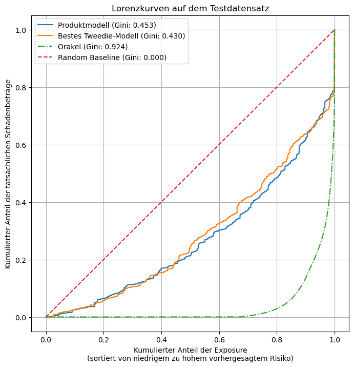

|  | model_name | gini_index |
| --- | --- | --- |
| 0 | Orakel | 0.923853 |
| 1 | Produktmodell | 0.452715 |
| 2 | Bestes Tweedie-Modell | 0.430239 |
| 3 | Random Baseline | 0.000000 |

```python
# ============================================================
# Lorenzkurven berechnen
# ============================================================

models_for_lorenz = {
    "Produktmodell": y_pred_product_test,
    "Bestes Tweedie-Modell": y_pred_best_tweedie_test,
    "Orakel": y_pred_oracle_test
}

lorenz_results = {}

for model_name, y_pred in models_for_lorenz.items():
    cum_exposure, cum_claims = lorenz_curve(
        y_true=y_true_test,
        y_pred=y_pred,
        exposure=exposure_test
    )

    gini = gini_index_from_lorenz(
        cumulative_exposure=cum_exposure,
        cumulative_claim_amount=cum_claims
    )

    lorenz_results[model_name] = {
        "cum_exposure": cum_exposure,
        "cum_claims": cum_claims,
        "gini": gini
    }


# ============================================================
# Diagramm erstellen
# ============================================================

plt.figure(figsize=(8, 8))

# Produktmodell
plt.plot(
    lorenz_results["Produktmodell"]["cum_exposure"],
    lorenz_results["Produktmodell"]["cum_claims"],
    label=f"Produktmodell (Gini: {lorenz_results['Produktmodell']['gini']:.3f})"
)

# Bestes Tweedie-Modell
plt.plot(
    lorenz_results["Bestes Tweedie-Modell"]["cum_exposure"],
    lorenz_results["Bestes Tweedie-Modell"]["cum_claims"],
    label=f"Bestes Tweedie-Modell (Gini: {lorenz_results['Bestes Tweedie-Modell']['gini']:.3f})"
)

# Orakel
plt.plot(
    lorenz_results["Orakel"]["cum_exposure"],
    lorenz_results["Orakel"]["cum_claims"],
    linestyle="-.",
    label=f"Orakel (Gini: {lorenz_results['Orakel']['gini']:.3f})"
)

# Random Baseline
plt.plot(
    [0, 1],
    [0, 1],
    linestyle="--",
    label="Random Baseline (Gini: 0.000)"
)

plt.title("Lorenzkurven auf dem Testdatensatz")
plt.xlabel("Kumulierter Anteil der Exposure\n(sortiert von niedrigem zu hohem vorhergesagtem Risiko)")
plt.ylabel("Kumulierter Anteil der tatsächlichen Schadenbeträge")
plt.legend(loc="upper left")
plt.grid(True)
plt.show()


# ============================================================
# Gini-Werte zusätzlich als Tabelle
# ============================================================

gini_results_df = pd.DataFrame([
    {
        "model_name": model_name,
        "gini_index": values["gini"]
    }
    for model_name, values in lorenz_results.items()
])

gini_results_df = pd.concat([
    gini_results_df,
    pd.DataFrame([{
        "model_name": "Random Baseline",
        "gini_index": 0.0
    }])
], ignore_index=True)

gini_results_df.sort_values(
    by="gini_index",
    ascending=False
).reset_index(drop=True)
```

#### Interpretation der Lorenzkurven

Je weiter eine Modellkurve unterhalb der Random-Baseline liegt, desto besser kann das Modell Policen nach ihrem Schadenrisiko sortieren. Das Orakel-Modell stellt die theoretisch beste Sortierung dar, da es die tatsächlichen Schadenbedarfe kennt.Der Gini-Index fasst diese Ranking-Qualität numerisch zusammen: Ein höherer Gini bedeutet, dass das Modell Policen mit hohem Schadenbedarf besser von Policen mit niedrigem Schadenbedarf trennt.

Die Lorenzkurven zeigen, dass sowohl das Produktmodell als auch das beste Tweedie-Modell eine deutlich bessere Risikosortierung liefern als die Random Baseline, da beide Kurven klar unterhalb der Diagonalen liegen. Das Produktmodell erreicht mit einem Gini von $0.453$ eine etwas bessere Ranking-Qualität als das beste Tweedie-Modell mit einem Gini von $0.430$. Insgesamt deutet das Diagramm darauf hin, dass das Produktmodell die Policen auf dem Testdatensatz etwas besser nach Schadenrisiko ordnet als das direkte Tweedie-Modell.

Dabei ist zu beachten, dass der Gini-Index nur die Sortierung bewertet und keine Aussage darüber trifft, ob die vorhergesagten Schadenbeträge im absoluten Niveau korrekt kalibriert sind. Deshalb wird zusätzlich die Balance Property überprüft.

### Balance Property überprüfen

Für den Kalibrierungs-Check wird geprüft, ob die Summe der vorhergesagten aggregierten Schadenbeträge ungefähr der Summe der tatsächlich beobachteten Schadenbeträge entspricht. Da die Modelle die Pure Premium vorhersagen, wird jede Vorhersage mit der Exposure multipliziert. Ein Verhältnis nahe bei 1 spricht für eine gute Kalibrierung auf Portfolioebene.

```python
# ============================================================
# Balance Property / Kalibrierungs-Check
# ============================================================

def balance_property_ratio(y_true, y_pred, exposure):
    """
    Verhältnis:
    Summe vorhergesagte Schäden / Summe tatsächliche Schäden

    Da y_pred und y_true Pure Premiums sind, wird jeweils mit Exposure multipliziert.
    """

    y_true = np.asarray(y_true, dtype=float)
    y_pred = np.asarray(y_pred, dtype=float)
    exposure = np.asarray(exposure, dtype=float)

    actual_total = np.sum(y_true * exposure)
    predicted_total = np.sum(y_pred * exposure)

    ratio = predicted_total / actual_total

    return predicted_total, actual_total, ratio


pred_product_total, actual_total, balance_product = balance_property_ratio(
    y_true=y_true_test,
    y_pred=y_pred_product_test,
    exposure=exposure_test
)

pred_tweedie_total, actual_total, balance_tweedie = balance_property_ratio(
    y_true=y_true_test,
    y_pred=y_pred_best_tweedie_test,
    exposure=exposure_test
)

balance_results_df = pd.DataFrame([
    {
        "model_name": "Produktmodell",
        "predicted_total_claim_amount": pred_product_total,
        "actual_total_claim_amount": actual_total,
        "balance_ratio_predicted_to_actual": balance_product
    },
    {
        "model_name": "Bestes Tweedie-Modell",
        "predicted_total_claim_amount": pred_tweedie_total,
        "actual_total_claim_amount": actual_total,
        "balance_ratio_predicted_to_actual": balance_tweedie
    }
])

balance_results_df
```

|  | model_name | predicted_total_claim_amount | actual_total_claim_amount | balance_ratio_predicted_to_actual |
| --- | --- | --- | --- | --- |
| 0 | Produktmodell | 943813.076594 | 1242251.390000 | 0.759760 |
| 1 | Bestes Tweedie-Modell | 772460.377750 | 1242251.390000 | 0.621823 |

### Interpretation der Balance Property und Modellwahl

Die Balance Property ist bei beiden Modellen nicht vollständig erfüllt, da das Verhältnis aus vorhergesagtem zu tatsächlichem Gesamtschaden deutlich unter $1$ liegt. Das Produktmodell sagt insgesamt etwa $76.0%\%$ des tatsächlichen Schadenabedarfs voraus und unterschätzt den Gesamtschaden damit um rund $24.0\%$. Das beste Tweedie-Modell sagt nur etwa $62.2\%$ des tatsächlichen Schadenbedarfs voraus und unterschätzt den Gesamtschaden somit noch stärker.

Damit ist das Produktmodell nicht nur hinsichtlich der Ranking-Qualität besser, da es einen höheren Gini-Wert erzielt, sondern auch besser kalibriert als das beste Tweedie-Modell. In der Praxis würde ich ein Modell bevorzugen, das eine gute Balance zwischen Ranking-Qualität und Kalibrierung bietet. Wenn jedoch zwischen beiden Eigenschaften entschieden werden muss, ist für die Tarifierung die Kalibrierung besonders wichtig, da das Modell den gesamten erwarteten Schadenabedarf möglichst korrekt treffen sollte. Ein Modell mit gutem Gini, aber schlechter Kalibrierung kann zwar Risiken gut sortieren, würde aber ohne Nachkalibrierung zu einem falschen Prämienniveau führen.

f) Modellvergleich und Empfehlung

Erstellen Sie eine Vergleichstabelle mit allen Modellen. Geben Sie im Anschluss eine begründete Modellempfehlung für die Praxis. Berücksichtigen Sie dabei sowohl Vorhersagegenauigkeit als auch Interpretierbarkeit, Trainingszeit und versicherungstechnische Plausibilität.

## **Lösung:**

Für den Modellvergleich werden alle geschätzten Pure-Premium-Modelle anhand der gewichteten Tweedie Deviance auf Trainings-, Validierungs- und Testdaten verglichen. Zusätzlich werden, soweit verfügbar, Optimierungs- und Trainingszeiten sowie fachliche Aspekte wie Interpretierbarkeit und versicherungstechnische Plausibilität berücksichtigt. Entscheidend für die finale Bewertung ist insbesondere die Performance auf dem Testdatensatz, da sie die Generalisierungsfähigkeit der Modelle am besten widerspiegelt.

```python
# Vergleichstabelle nach Test-Tweedie-Deviance sortieren
pure_premium_results_df.sort_values(
    by="tdw_test",
    ascending=True
).reset_index(drop=True)

pure_premium_results_df
```

|  | model_name | tweedie_power | tdw_train | tdw_valid | tdw_test | opt_time_sec | fit_time_sec | notes |
| --- | --- | --- | --- | --- | --- | --- | --- | --- |
| 0 | Produkt: LightGBM × Gamma GAM | 1.900000 | 25.412106 | 26.110841 | 26.001551 | 59.133909 | 1.505707 | Frequency_Model=LightGBM,Severity_model=Gamma GAM |
| 1 | LightGBM Tweedie | 1.900000 | 24.780213 | 26.225340 | 26.451388 | 62.352127 | 0.185769 | LightGBM mit objective=tweedie; Grid Search üb... |
| 2 | GLM Tweedie | 1.800000 | 25.196639 | 25.400808 | 28.210916 | 2.828929 | 0.037155 | Direktes Pure-Premium-Modell; Grid Search über... |
| 3 | XGBoost Tweedie | 1.800000 | 24.381561 | 25.053805 | 28.358688 | 237.005093 | 0.456653 | XGBoost mit objective=reg:tweedie; Grid Search... |

### Modellvergleich und Empfehlung

Die Vergleichstabelle zeigt, dass das **Produktmodell aus LightGBM und Gamma-GAM** auf dem Testdatensatz die niedrigste Tweedie Deviance erreicht. Mit einer Test-Deviance von 26.0016 liefert es die beste Vorhersagegenauigkeit auf ungesehenen Daten. Das **LightGBM-Tweedie-Modell** folgt mit einer Test-Deviance von 26.4514 knapp dahinter, während das **GLM-Tweedie-Modell** und das **XGBoost-Tweedie-Modell** deutlich höhere Test-Deviances aufweisen.

Das GLM-Tweedie-Modell ist zwar sehr schnell zu trainieren und gut interpretierbar, erreicht aber nicht die beste Prognosegüte. Sein Vorteil liegt vor allem in der einfachen Struktur, der direkten Modellierung der Pure Premium und der guten statistischen Nachvollziehbarkeit. Allerdings kann ein GLM komplexe nichtlineare Effekte und Interaktionen nur begrenzt erfassen, sofern diese nicht explizit modelliert werden.

Zusammenfassend ist das Produktmodell aufgrund seiner besten Test-Deviance, guten Ranking-Qualität und fachlichen Plausibilität das bevorzugte Modell. Vor einer praktischen Anwendung sollte jedoch die Kalibrierung verbessert werden, da ein Modell mit guter Risikosortierung, aber schlechter Balance Property zu einem falschen Prämienniveau führen kann. In der Praxis wäre daher das Produktmodell nach zusätzlicher Kalibrierung die geeignetste Wahl.

# HTML Datei generieren

```python
!jupyter nbconvert --to html --template lab TeilB.ipynb
```

```
[NbConvertApp] Converting notebook TeilB.ipynb to html
[NbConvertApp] Writing 3312288 bytes to TeilB.html
```